# Semantic Annotation of Nouns

# Introduction

In this file I will go through the annotations and clouds of 8 nouns: *horde, hoop, spot, staal, stof, schaal, blik, spoor*. For each of them, I will show the sense distribution, a sort of confusion matrix and a description of the clouds. The descriptions can still go much deeper; I’m prioritizing an overview of the possibilities and variation across lemmas before going too deep into each of them. At the same time, they are still only descriptions and I’m not drawing conclusions from them yet, so beyond this introduction the rest is not summarized yet.

## Sense distribution

For all the cases we have at least two homonyms, of which at least one is polysemous. The sense tags have codes described in a table with definitions at the beginning of each section, but the annotators also had the option of assigning a *geen* ‘none of the above’ tag, in which case they had to add an explanatory comment.

When setting up the annotation procedure, I collected pilot batches of 40-50 concordance lines of each type to estimate the frequency of the senses we expected (we did have to exclude candidates because some sense was not frequent enough). My annotation was not extremely thorough and sometimes we modified the definition set afterwards, so it’s best to keep that in mind when reading the comparison between the distribution I found and what came out of the annotations. I think it’s worthy to consider that if my estimates over samples of 40-50 tokens match what we find in a bigger sample (and especially if it’s robust across batches) it’s quite encouraging. If (the skewness of) the sense distribution turns out to be a factor in the topology of the clouds, it’s useful to know that it can be estimated from such a small sample.

The **Sense distribution** subsection of each section compares then the estimated sense distribution based on the pilot concordances with the one found in each batch and the whole set of tokens. For each type a plot is shown with a row of dots per batch over a line and two more rows below the line representing my estimate and the overall distribution. Circle dots represent tokens tagged with a given sense by the majority of the annotators (each sense has a color) and triangles represent either tokens primarily annotated with the *geen* ‘none of the above’ tag or tokens for which the annotators did not agree at all. The dots in the batch rows represent one token each and their transparency codes the mean confidence after standardizing its value by annotator and lemma.

## Confusion matrix

For each type, two confusion matrices will be shown. In each of them, a row represents a majority sense (or *no_agreement* if there was no majority) and a column represents a sense tag. By hovering over the row names it’s possible to retrieve the definition, since the tags are not precisely transparent; columns are also grouped by homonym. Since the *geen* ‘none of the above’ tags can have different reasons, I classified the annotators’ explanations with the following tags:

- *between*, when the annotator reported doubt between two or more of the given senses;
- *other_sense*, when the explanations referred to either a sense that was not contemplated in the list of senses or to a proper noun (or should that be *wrong_lemma*?);
- *unclear*, when the explanations referred to either insufficient or unclear context (or simply difficulty to understand, such as “geen flauw idee”), and
- *wrong_lemma*, when they referred to an issue with lemmatization, part-of-speech tagging or even spelling, so that the target didn’t actually correspond to what was meant to be annotated.

The first matrix shows raw annotation counts. Each cell tells the number of tokens with the majority sense of the row that were tagged with the sense of the column: The cell in the row of *horde_1* and the column *horde_3* will say how many tokens with the majority sense *horde_1* received some *horde_3* annotation. The totals indicate the number of tokens that had a certain majority sense (for row totals) or were tagged with a given sense (for column totals). Initally I’m only paying attention at which senses are confused with each other. The caption also records the proportion of tokens with a certain majority sense or homonym that received the same tag from all annotators.

The second matrix shows the mean of the mean confidences of the annotations. Suppose the row is *horde_1* and the column is *horde_3*; to fill in such a cell, I take all tokens with majority sense *horde_1*, and for each of them I calculate the mean of the confidences of the *horde_3* annotations. Then I compute the mean of those means, and report the resulting value in the table. Here it is important to take into account that the annotators had to assign senses rather than homonyms: very often, the disagreement between sense annotations becomes agreement between homonym choices; I expect the same happens when confidence ratings are low in polysemous items.

## Nephology

For each type I describe the role of the parameters in the structure of the cloud of clouds (level 1 of the [visualization](http://montesmariana.github.io/NephoVis/)) showing two color coded plots, and then compare sets of models (level 2). In principle I first fix parameters that seem to have little to no effect in the variation between models and compare the resulting selection; then briefly look at other combinations that might provide different results, and finally fix parameters that seem to provide “satisfying” models to look at the actual effect of the less important parameters. Normally, the strongest ones are those that select first order context features, while the second order parameters rarely make much of a difference.

The comparison between models normally takes the following steps:

1. examine the range of distances between the models through the distance matrix;
2. describe the general look of the clouds without color coding and how they change between MDS and t-SNE solutions;
3. color code with homonym tags and describe the revealed structure;
4. color code with sense tags and describe the revealed structure.

The description includes the behaviour of outliers in MDS solutions, the separability of homonyms/senses in any kind of solutions, how many and how clear clusters show up in the different t-SNE solutions (if there is any that provides a particularly good representation, how robust it is across different perplexities) and how such structure relates to the parameters under comparison. For now, I don’t look at individual tokens but on an exceptional basis. I acknowledge a certain bias: I tend to prefer certain settings (from theoretical reasons sometimes, but not always) and the findings in one type definitely affect how I look at the following ones. I hope time and experience will give me the tools to revise my decisions with better criteria.

Finally, I suggest a next course of action, such as which model(s) I would like to look into and which tokens seem interesting to look at. That is highlighted in a nice quote block at the end of each section.

To ease the descriptions, the parameters will be written in all caps and their values will follow them separated by colon. These are:

**First order part-of-speech (`FOC-POS`)**

Can take the value `FOC-POS:nav`, when only nouns, adjectives and verbs were selected as first order features, or `FOC-POS:all`, when there was no such restriction (still, some part-of-speech tags *were* ignored always, such as interjections).

I would tend to default to `FOC-POS:nav`, since function words are probably less informative (kind of linguistically informed default).

**First order window (`FOC-WIN`)**

Can take the value `FOC-WIN:5`, when only features within a 5-5 window of the target were included, or `FOC-WIN:10`, when a 10-10 window was used.

I default to `FOC-WIN:10`, to allow for more information; normally relying on other restrictions is enough to filter out the noise.

**Positive pointwise mutual information as filter (`PPMI`)**

Can take the value `PPMI:weight` when the second order vectors are weighted by the PPMI value between the first order feature they represent and the target type, `PPMI:selection` when only features with a positive PMI with the target type were included but the vectors were not weighted, and `PPMI:no` when no such filter was applied. Normally, the models with `PPMI:selection` are more similar to `PPMI:no` than to `PPMI:weight` and I don’t consider them in the initial comparisons.

I would default to `PPMI:no`, since a high PPMI value signals a feature as characteristic of the type rather than of groups of it (like a sense), but in the analyses described in this file it never performs as well as the alternatives.

**Vector length (`LENGTH`)**

Can take the values `LENGTH:5000` and `LENGTH:10000` when the 5000/10000 most frequent features were used as second order dimensions, or `LENGTH:FOC` when the same first order dimensions are used for the second order. That means that their number and frequency depends on the result of the first order restrictions for that particular sample of tokens. Normally, while this is not an extremely strong parameter, `LENGTH:FOC` can make a different against the other two, frequency based values.

I default to `LENGTH:FOC` because it should be better tailored to the specific context of the tokens in the cloud; it’s harder to compare clouds with different first order context words, but it does seem to perform better in most cases. Between frequency based values, I almost never look at `LENGTH:10000`, since it almost never seems to make much of a difference, but I probably should look into it before discarding it from future clouds. If both frequency based settings perform very similarly, smaller numbers should be preferred (hence the tendency to choose `LENGTH:FOC` as well, since it normally means fewer than 5000 dimensions).

**Second order part-of-speech (`SOC-POS`)**

Can take the values `SOC-POS:nav` or `SOC-POS:all` and refers to a filter on the second order dimensions. This never makes much of a difference.

I default to `SOC-POS:nav` because so does Stefano (should read why).

**Second order window (`SOC-WIN`)**

Can take the values `SOC-WIN:4` or `SOC-WIN:10` depending on whether the `PPMI` values for the second order vectors were computed based on a 4-4 or 10-10 window.

This parameter seems to group models for some types, but doesn’t really affect the structure of the clouds that much as far as I can see. I default to `SOC-WIN:4` because so does Stefano (should read why). Could it be that in the cases where it seems relevant, what actually happens is that all the other parameters are just too weak?

Eventually, I would like to reinstate sentence boundary as parameter (replacing for example `SOC-POS`). The difference between `LENGTH:5000` and `LENGTH:10000` also seems disposable.

# *horde*

The noun *horde* was tagged with 3 definitions, reproduced in Table 1. The homonyms are roughly equivalent to English ‘horde’ (*horde_1*) and ‘hurdle’, which can be a literal obstacle, particularly in sports (*horde_2*) or figurative (*horde_3*). The first homonym is estimated (based on a 40-token sample) to be much more frequent than the second, but clearly distinguishable from it. While the two senses of the second homonym are quite distinct, depending on the clarity of the context there could be some overlap in the annotations of senses within the second homonym.

Table 1. Definitions of ‘horde’.

| code | definition | example | freq |
| --- | --- | --- | --- |
| horde_1 | 1 bende, ordeloze groep personen | een woeste horde | 26 |
| horde_2 | 2.1 materiële hindernis, m.n. houten raamwerk gebruikt bij het hordelopen | de 400m horden bij de vrouwen | 5 |
| horde_3 | 2.2 hindernis in figuurlijke zin | een horde nemen | 8 |

## Sense distribution

The sample consists of 280 tokens (7 batches) out of 3224 occurrences in the QLVLNewsCorpus; the distribution of the majority senses of each batch, as well as my estimate and the overall distribution, are reproduced in Figure 1.

As estimated, the first homonym tends to be the most frequent, with at least half the tokens of each batch, and between the senses of the second homonym, the figurative one tends to be more frequent. The only exception is the seventh batch, where a huge majority of the tokens was tagged with the literal “hurdle” sense. I checked the concordance and they are correctly tagged. In any case, the overall distribution is very similar to the estimated one.

> “horde” is a noun with two homonyms of very different frequencies, where the least frequent homonym is polysemous with two senses of similar frequency.

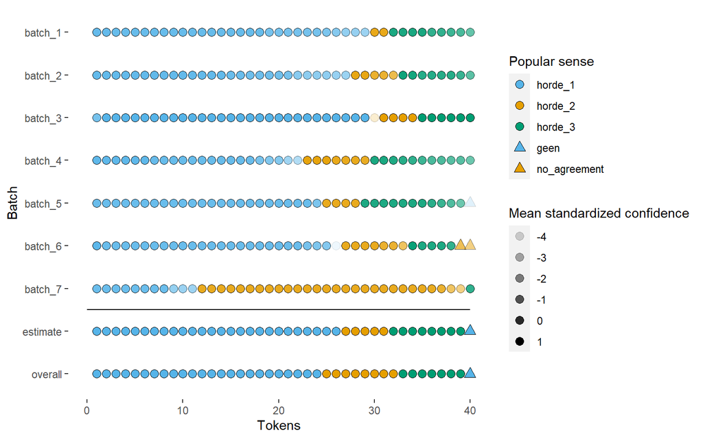

Figure 1. Distribution of majority senses of ‘horde’ per batch

## Confusion matrix

The confusion matrix between the majority senses and other tagged senses can be seen in Table 2 (raw number of tokens with such senses assigned) and Table 3 (mean confidence of such sense annotation in each token).

We would expect no confusion between *horde_1* ‘horde’ on one side and the others (literal and figurative ‘hurdle’). There are, however, 7 (out of 280) tokens present an annotation that confuses homonyms. While an inspection of the concordances shows that the majority sense tag is quite straightforward, this discrepancy could be taken into account while looking at the clouds.

There are also 11 cases where some annotator thought the given options didn’t apply (*other_sense* column); the 10 cases of ‘horde’ are applied to non-human entities, and the annotators resisted tagging them with a sense that specified “people”. Only two tokens presented no agreement between annotators (total of the *no_agreement* row).

Table 2. Non weighted sense matrix of ‘horde’ senses. Proportion of tokens with full agreement per sense-tag is: horde_1: 0.89, horde_2: 0.86, horde_3: 0.86. Proportion of tokens with full agreement per homonym is: horde: 0.89, hurdle: 0.95.

| senses | horde horde_1 | hurdle horde_2 | hurdle horde_3 | geen between | geen other_sense | geen unclear | total |
| --- | --- | --- | --- | --- | --- | --- | --- |
| horde_1 | 168 | 3 | 3 | 0 | 10 | 3 | 168 |
| horde_2 | 1 | 58 | 7 | 0 | 0 | 1 | 58 |
| horde_3 | 0 | 6 | 51 | 0 | 1 | 0 | 51 |
| unclear | 0 | 0 | 1 | 0 | 0 | 1 | 1 |
| no_agreement | 0 | 2 | 2 | 1 | 0 | 1 | 2 |
| total | 169 | 69 | 64 | 1 | 11 | 6 | 0 |

The weighted matrix shows that there is a relatively high mean confidence in the annotations that became majority senses, and a relatively lower one in the disagreeing annotations. It is remarkable, however, that the one annotation that assigned *horde_1* ‘horde’ to a majority *horde_2* ‘lit. hurdle’ token had the maximum confidence. The concordance of such token is reproduced in (1).

1. ABN Amro signaleert een vangnet aan de onderkant rond de 575 punten en een ’ horde ’ op 610 . Breekt de AEX door het niveau van 610 heen ,

Table 3. Weighted sense matrix of ‘horde’ senses

| senses | horde horde_1 | hurdle horde_2 | hurdle horde_3 | geen between | geen other_sense | geen unclear |
| --- | --- | --- | --- | --- | --- | --- |
| horde_1 | 4.58 | 3.33 | 3 | 0 | 4 | 3 |
| horde_2 | 5 | 4.7 | 3.21 | 0 | 0 | 0 |
| horde_3 | 0 | 3.5 | 4.33 | 0 | 0 | 0 |
| unclear | 0 | 0 | 2 | 0 | 0 | 1.5 |
| no_agreement | 0 | 3.5 | 3.5 | 4 | 0 | 4 |

## Nephology of *horde*

My first impression on the clouds relates to the stress values of the dimensionality reduction and the parameters that make the strongest distinctions between models. We have 144 models of *horde* created on 10/03/2020, modelling between 262 and 279 tokens. The stress value of the MDS solution for the cloud of models is 0.161.

The parameters with a stronger effect in the distinction between the models are `FOC-POS` and `PPMI` (with the biggest difference between `PPMI:weight` on one side, and `PPMI:selection` or `PPMI:no` on the other, see Figure 2), and then `FOC-WIN` (see Figure 3); second order parameters seem to have a minimal effect. The stress values of the MDS solutions of these models range between 0.105 and 0.254

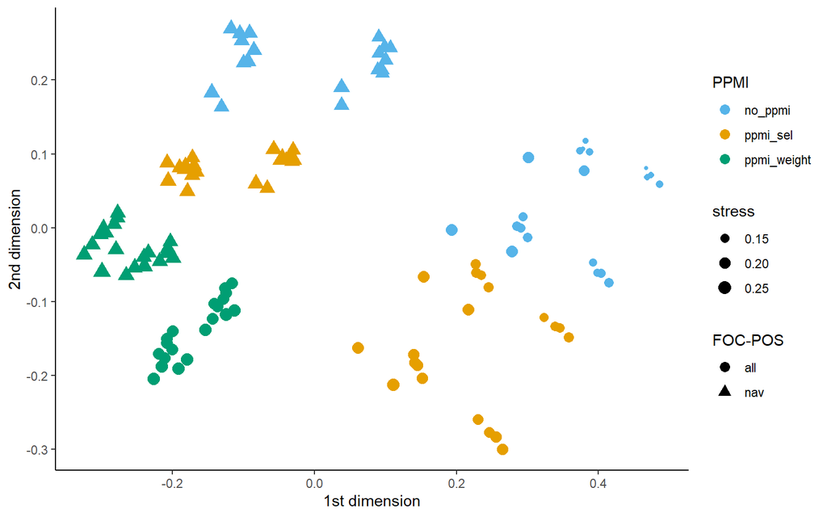

Figure 2. Cloud of models of ‘horde’ colored by `PPMI`. Explore it [here](https://montesmariana.github.io/NephoVis/level1.html?type=horde).

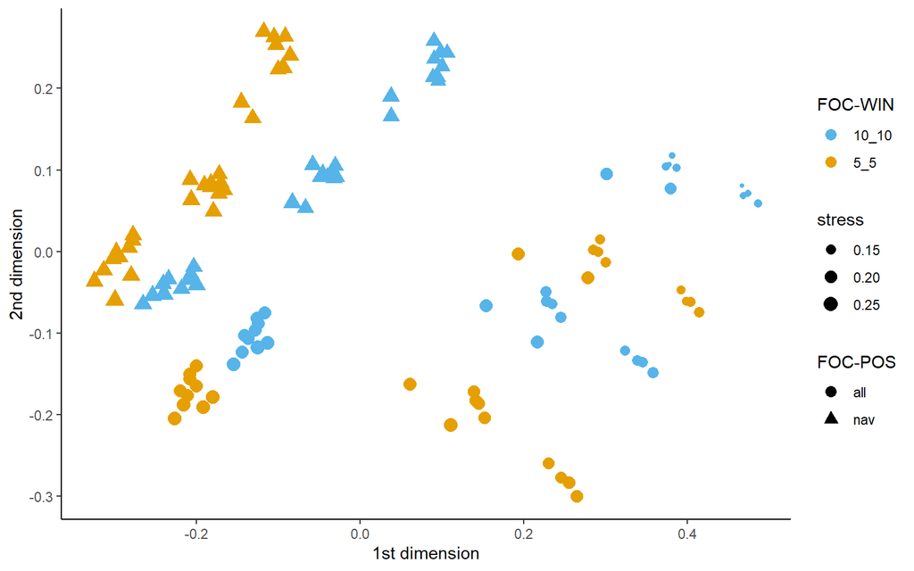

Figure 3. Cloud of models of ‘horde’ colored by `FOC-WIN`. Explore it [here](https://montesmariana.github.io/NephoVis/level1.html?type=horde).

To compare the models, we will first fix `SOC-POS:nav + SOC-WIN:4 + LENGTH:FOC` constant while varying along the other three variables. We’ll ignore `PPMI:selection`, since for that variable the greatest difference seems to lie between `PPMI:weight` and the other two. Looking at the distance matrix between the corresponding clouds, the one with the looser filters seems to be the most different to the rest, with the most similar model being the one that only restricts window size (distance of 0.24), followed by the one that only restricts part-of-speech (distance of 0.39). The three models that restrict window size and something else (either `PPMI`, `FOC-POS` or both) seem to be the most similar to each other, with distances between 0.1 and 0.29.

Given this selection, we’ll compare the results from MDS and t-SNE with different levels of perplexity. Some t-SNE models at some levels of perplexity (mainly from 20 upwards, and with increasing clarity) show some pockets of tokens (particularly models that almost seem to have “pockets” in MDS).

The MDS solutions with `PPMI:no` are more susceptible to outliers: the largest part of the cloud is crammed around the center, taking distance from a couple of single tokens. This doesn’t seem to bother the t-SNE solutions, although those tokens do tend to occur in the periphery of their subclouds. The homonyms form two distinct hemispheres, so to speak, and the senses of the second homonym are clear enough as well, particularly in the models with `FOC-POS` and/or `PPMI` filters. Sometimes, the figurative tokens are too widely spread.

Regarding the t-SNE solutions, clusters are hard to identify with perplexity of 5 (unless color-coded), and then they are more clear-cut in the `PPMI:weight` models: there is a big cloud of *horde_1* ‘horde’ and then two smaller clouds of *horde_2* and *horde_3* respectively (literal and figurative ‘hurdle’). There are still some tokens between the clear clusters, but they don’t seem to persist across models. If we include the `PPMI:selection`, we can see it works better than `PPMI:no` (which is quite bad) but not much worse than `PPMI:weight`.

If we fix the first order parameters, the second order parameters seem to have little to no effect; the resulting distance matrices seem to rarely have a value over 0.18. `LENGTH:FOC` seems to have a bit more of an effect if there are no first order filters, but the difference is more evident in the MDS solutions (the `LENGTH:FOC` models are less sensitive to the outliers); looking at the distance matrices, it’s really not so strong.

All in all, the `FOC-POS:nav` models seem better than their `FOC-POS:all` counterparts; and `FOC-WIN:5` looks better than `FOC-WIN:10` only for `FOC-POS:all` in the MDS solution. (By better, I mean more distinct subclouds; less clutter and yuxtaposition… I should compare my assessments with actual measures.)

> For deeper insight I will look at models with `FOC-WIN:10 + FOC-POS:nav + SOC-WIN:4 + SOC-POS:nav`, comparing across all `PPMI` values and between `LENGTH:FOC` and `LENGTH:5000`.

### Oultiers (MDS solutions)

The outliers are two tokens with only one relevant –and rather infrequent– context word and a concordance in French.[^1] The most problematic are (2) and (3), where the only surviving context word is *kad/noun* (I don’t understand what it means, really). The problem is likely that there is only one surviving context word with a rather low frequency (226) but therefore a high PPMI (5.52), which might lead to a rather sparse vector with `LENGTH:5000 | LENGTH:10000`. Since the context word is rather linked to the context of the target, the `LENGTH:FOC` vectors are not so problematic. While they remain outliers in all models, they skew them less when either `PPMI:weight` or `FOC-POS:nav` filters are applied and even less with `LENGTH:FOC`. These tokens also tend to be peripheric in the t-SNE models.

2. ) 8.19 . David Palinckx ( ABES ) 7.84 . 60^m horden 0,914 ( *kad* ) : Wim Marynissen ( AVKA ) 9.80 .
3. 400m horden ( sch-2de reeks ) : 1. Shaun Malone ( ACBR ) 59.22 300m horden ( *kad* ) : 1. Eri Van Vosselen ( SWIN ) 44.05 Ver ( sen

When the power of (2) and (3) are cancelled, the other outlier comes out: (4). Here, if there are no filters, the words *et*, *les* and *de* are counted; the `FOC-POS:nav` filter excludes *de* because it’s tagged as a determiner (while the others are tagged as nouns!) and a `PPMI` filter discards *les* because of its negative PMI with the target. (4) remains consistently an outlier, and rather peripheric in t-SNE models.

4. pour entendre ’ au secours ’ Où sont passés *les* baobas *et* *les* hordes *de* gosses Dans cette ère de négoce où ne vivent que les big

# *hoop*

The noun *hoop* was tagged with 3 definitions, reproduced in Table 4. The homonyms are roughly equivalent to ‘lot/pile/bunch’ (*hoop_1* in the concrete, specific sense; *hoop_2* in the broader sense of ‘a lot of…’) and ‘hope’ (*hoop_3*). The second homonym is expected to be much more frequent than the first one and very easy to distinguish from it; the first one is not only polysemous but inbalanced in the frequency of its senses and highly dependent on the specificity of the context for a confident distinction between them.

Table 4. Definitions of ‘hoop’.

| code | definition | example | freq |
| --- | --- | --- | --- |
| hoop_1 | 1.1 ongeordende stapel | een hoop rommel, gooi maar op de hoop | 1 |
| hoop_2 | 1.2 grote hoeveelheid | een hoop mensen, een hele hoop geld | 10 |
| hoop_3 | 2 positieve verwachting, vertrouwen op iets positiefs | hoop koesteren, de hoop uitspreken dat… | 28 |

## Sense distribution

> “hoop” is a noun with two homonyms of very different frequencies, where the least frequent homonym is polysemous with two senses of different frequencies.

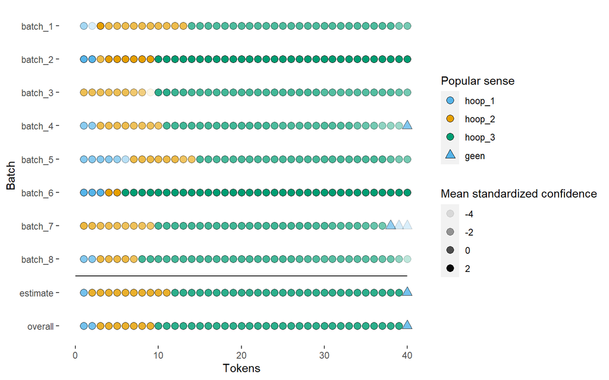

Figure 4. Distribution of majority senses of ‘hoop’ per batch

## Confusion matrix

The confusion matrix between the majority senses and other tagged senses can be seen in Table 5 (raw number of tokens with such senses assigned) and Table 6 (mean confidence of such sense annotation in each token). Ideally, there would be no confusion between *hoop_1* and *hoop_2* on one side and *hoop_3* on the other. Indeed, there are only 4 cases, tagged primarily with *hoop_3* ‘hope’, where some annotator also assigned a sense tag of the other homonym. While the concordances for those tokens are not the most clear (especially on a tired mind), the majority senses are indeed correct. They could still be interesting to look up in the clouds. For the rest, there are very few that couldn’t be assigned a sense and no cases without any agreement at all.

Table 5. Non weighted sense matrix of ‘hoop’ senses. Proportion of tokens with full agreement per sense-tag is: hoop_3: 0.96, hoop_2: 0.86, hoop_1: 0.65, other_sense: 1. Proportion of tokens with full agreement per homonym is: hope: 0.96, pile: 1, geen: 0.5.

| senses | pile hoop_1 | pile hoop_2 | hope hoop_3 | geen other_sense | geen unclear | geen wrong_lemma | total |
| --- | --- | --- | --- | --- | --- | --- | --- |
| hoop_1 | 17 | 6 | 0 | 0 | 0 | 0 | 17 |
| hoop_2 | 8 | 59 | 0 | 0 | 0 | 0 | 59 |
| hoop_3 | 1 | 3 | 240 | 0 | 3 | 3 | 240 |
| other_sense | 0 | 0 | 0 | 1 | 0 | 0 | 1 |
| unclear | 0 | 0 | 1 | 1 | 2 | 0 | 2 |
| wrong_lemma | 0 | 0 | 1 | 0 | 0 | 1 | 1 |
| no_agreement | 0 | 0 | 0 | 0 | 0 | 0 | 0 |
| total | 26 | 68 | 242 | 2 | 5 | 4 | 0 |

The weighted matrix (Table 6) shows a relatively high confidence in the agreeing annotations compared to the disagreeing ones. One curious case is a token where two annotators assigned a *geen* tag with minimum confidence and reported to be quite lost in the meaning of the expression and the other very confidently (maximum confidence) assigned a *hoop_3* ‘hope’ tag. The concordance is reproduced in (5).

5. het leukste speelgoed . Van het oorspronkelijke dierenbestand van het park blijven op dit ogenblik **hoop** en al één lama , enkele herten en drie pauwen over . Navraag leerde ons

Here the target is part of a fixed expression, “hoop en al” (is any of the current meanings still active there?); I should check when inspecting the cloud if there are other instances of it, how they are positioned and how they were tagged.

Table 6. Weighted sense matrix of ‘hoop’ senses

| senses | pile hoop_1 | pile hoop_2 | hope hoop_3 | geen other_sense | geen unclear | geen wrong_lemma |
| --- | --- | --- | --- | --- | --- | --- |
| hoop_1 | 4.72 | 4.5 | 0 | 0 | 0 | 0 |
| hoop_2 | 3.62 | 4.58 | 0 | 0 | 0 | 0 |
| hoop_3 | 3 | 3.33 | 4.71 | 0 | 1 | 2.33 |
| other_sense | 0 | 0 | 0 | 5 | 0 | 0 |
| unclear | 0 | 0 | 5 | 1 | 0.75 | 0 |
| wrong_lemma | 0 | 0 | 2 | 0 | 0 | 4 |
| no_agreement | 0 | 0 | 0 | 0 | 0 | 0 |

## Nephology of *hoop*

My first impression on the clouds relates to the stress values of the dimensionality reduction and the parameters that make the strongest distinctions between models. We have 144 models of *hoop* created on 10/03/2020, modeling between 298 and 317 tokens. The stress value of the MDS solution for the cloud of models is 0.17.

The cloud of models (Figure 5) has two clear groups divided by `FOC-POS` along the first dimension, and three clear groups within each of them based on the `PPMI`, with `PPMI:selection` between `PPMI:no` and `PPMI:weight` but closer to the former than to the latter. Within each of those groups, `FOC-WIN` draws divisions (Figure 6). The stress values of the MDS solutions of these models range between 0.237 and 0.317.

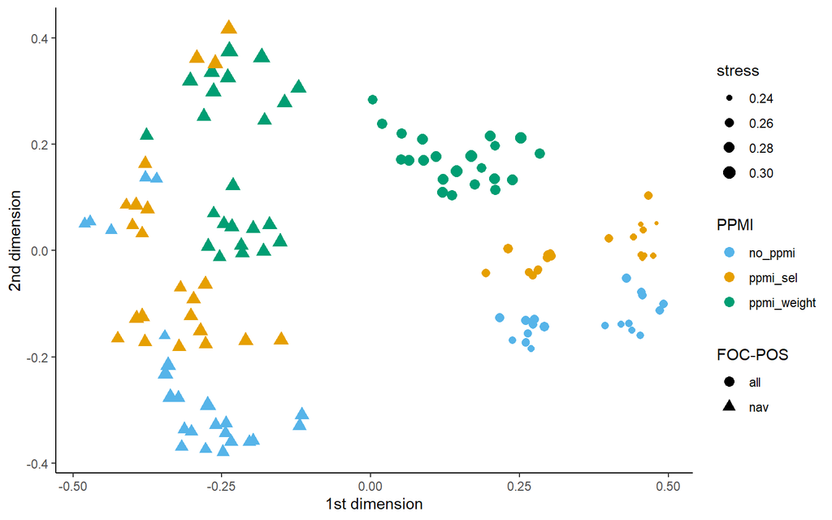

Figure 5. Cloud of models of ‘hoop’ colored by `PPMI`. Explore it [here](https://montesmariana.github.io/NephoVis/level1.html?type=hoop).

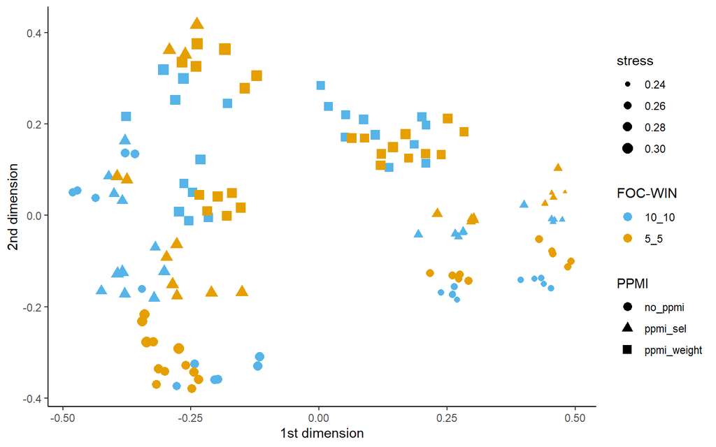

Figure 6. Cloud of models of ‘hoop’ colored by `FOC-WIN`. Explore it [here](https://montesmariana.github.io/NephoVis/level1.html?type=hoop).

The model with `FOC-WIN:5 + FOC-POS:all + PPMI:selection` looks in t-SNE like a pretty MDS model, and much better with `LENGTH:5000`.

When the weaker variables are fixed, values in the distance matrix range between 0.5 and 0.93 (between the strictest and the least strict `PPMI`), with three pairs of models of smaller distance. Other selection of weak variables seem to return similar results. When the stronger variables are fixed, values in the distance matrix range between 0.14 and 0.7, sometimes going higher or lower.

> The skewness in frequency seems to make “hoop” hard to model; I would like to look deeper into models with `FOC-WIN:5 + FOC-POS:all + PPMI:selection + LENGTH:5000`.

### Outliers

There is an evident outlier in some MDS clouds, (6). The annotators all agreed on assigning *hoop_3* ‘hope’, although with low confidence. It does make me want to review the low confidence cases.

6. van de BWB . *Wielrennen* : Tom Franssens en Dario Di Dio *verlaten* Hoop *op* Zegen - Wielerclub Hoop *op* Zegen Beveren *verliest* *twee* van zijn smaakmakers .

# *spot*

The noun *spot* was tagged with 3 definitions, reproduced in Table 7. The homonyms mean roughly “ridicule” (*spot_1*) and “spot(light)”, with a literal (or metaphorical) spotlight for *spot_3* and, metonymically, a videoclip for *spot_2*. The two homonyms have similar frequencies, as well as the two senses of the polysemous one, but a relatively high number of challenging tokens is expected.

Table 7. Definitions of ‘spot’.

| code | definition | example | freq |
| --- | --- | --- | --- |
| spot_1 | 1 oneerbiedige, ridiculiserende uitspraak of behandeling | de spot drijven met, bijtende spot | 14 |
| spot_2 | 2.1 reclameboodschap via radio, televisie, bioscoop | een spotje voor tandpasta | 9 |
| spot_3 | 2.2 schijnwerper | de spots richten op | 7 |

## Sense distribution

The sample consists of 240 tokens (6 batches) out of 3496 occurrences in the QLVLNewsCorpus; the distribution of the majority senses of each batch, as well as my estimate and the overall distribution, are reproduced in Figure 7.

While some batches have more skewed distributions (the first one has mainly “ridicule” cases and the sixth one, “spotlight” cases), the overall distribution resembles the estimated one, with fewer cases of ambiguous tokens but still rather balanced frequencies.

> “spot” is a noun with two homonyms of similar frequency, one of which has two senses of similar frequency.

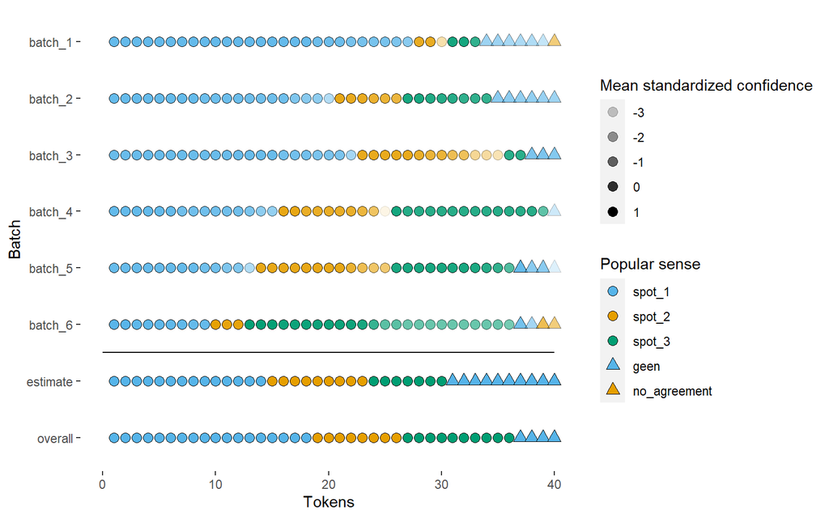

Figure 7. Distribution of majority senses of ‘spot’ per batch

## Confusion matrix

The confusion matrix between the majority senses and other tagged senses can be seen in Table 8 (raw number of tokens with such senses assigned) and Table 9 (mean confidence of such sense annotation in each token).

We would expect no confusion between *spot_1* ‘ridicule’ on one side and *spot_2* ‘videoclip’ and *spot_3* ‘spotlight’ on the other, but also rare confusion between the senses of the second homonym. It’s indeed the case that a very small number of tokens with one of these senses as majority sense received a tag from another sense; most of the confusion comes from tags like *unclear* and *other_sense*. In the *spot_3* ‘spotlight’ cases with *other_sense* tags, the annotators suggested that it might be referring to the name of a magazine – the concordances are indeed quite particular and similar to each other, so we could expect them to cluster in the clouds. There is also a strong group of tokens with *other_sense* as the majority sense: there, the target item is part of the English expression *hot spot*, and the annotators suggested the meaning of “place” and/or pointed out that it’s from English.

Table 8. Non weighted sense matrix of ‘spot’ senses. Proportion of tokens with full agreement per sense-tag is: spot_1: 0.96, spot_3: 0.77, spot_2: 0.77, other_sense: 0.84. Proportion of tokens with full agreement per homonym is: ridicule: 0.96, film/spotlight: 0.81, geen: 0.68.

| senses | ridicule spot_1 | film/spotlight spot_2 | film/spotlight spot_3 | geen between | geen other_sense | geen unclear | total |
| --- | --- | --- | --- | --- | --- | --- | --- |
| spot_1 | 106 | 0 | 2 | 1 | 0 | 1 | 106 |
| spot_2 | 3 | 47 | 4 | 0 | 1 | 3 | 47 |
| spot_3 | 0 | 0 | 62 | 0 | 11 | 3 | 62 |
| other_sense | 0 | 0 | 3 | 0 | 19 | 0 | 19 |
| unclear | 1 | 1 | 0 | 0 | 1 | 3 | 3 |
| no_agreement | 0 | 1 | 2 | 0 | 3 | 3 | 3 |
| total | 110 | 49 | 73 | 1 | 35 | 13 | 0 |

The confidence assignments in agreement are quite high, with a relatively low confidence for the *hot spot* group (*other_sense* row and column). The unexpected here is to see a mean confidence of 5 for the three cases where the popular sense tag referred to *spot_2* ‘videoclip’ but the minority sense to *spot_2* ‘ridicule’, a different homonym. They could be considere ambiguous, particularly if primed with other input.

7. mensen hier namelijk knedliky om hun hersenstam zitten . In vergelijking met de vrolijke **spot** van Cerný komt Pavel CZácek , de vroegere student journalistiek , dodelijk serieus over .
8. nieuwe partij Nieuw Rechts , omdat de inhoud te racistisch zou zijn . De **spot** is suggestief , racistisch en discrimineert , zegt commercieel directeur Theo van der Gun
9. was er enkel televisiereclame op de Franstalige zenders , maar plots moesten er ook Nederlandstalige **spots** ingesproken worden , zegt Ramaekers . Ook hij beaamt dat de sector de afgelopen

Table 9. Weighted sense matrix of ‘spot’ senses

| senses | spot_1 | spot_2 | spot_3 | between | other_sense | unclear |
| --- | --- | --- | --- | --- | --- | --- |
| spot_1 | 4.71 | 0 | 2.25 | 0 | 0 | 0 |
| spot_2 | 5 | 4.35 | 3 | 0 | 1 | 3.67 |
| spot_3 | 0 | 0 | 4.27 | 0 | 1.73 | 2.33 |
| other_sense | 0 | 0 | 1 | 0 | 3.4 | 0 |
| unclear | 4 | 3 | 0 | 0 | 0 | 1.17 |
| no_agreement | 0 | 3 | 4 | 0 | 3 | 0 |

## Nephology of *spot*

My first impression on the clouds relates to the stress values of the dimensionality reduction and the parameters that make the strongest distinctions between models. We have 144 models of *spot* created on 10/03/2020, modeling between 220 and 235 tokens. The stress value of the MDS solution for the cloud of models is 0.106.

The grouping of the cloud of models seems to come firstly from an interaction between `FOC-POS` and `PPMI`, so that the right half belongs to those with `FOC-POS:all + PPMI:selection | PPMI:no`, the bottom left quarter is populated by `PPMI:weight` models and the top left quarter by `FOC-POS:nav + PPMI:selection | PPMI:no` (Figure 8). Each smaller group defined by a combination of those two parameters is further split by `FOC-WIN` (Figure 9). Other parameters seem to have a very weak effect, although `LENGTH:FOC` seems to form a group within the `FOC-POS:nav` area. The stress values of the MDS solutions of these models range between 0.165 and 0.264.

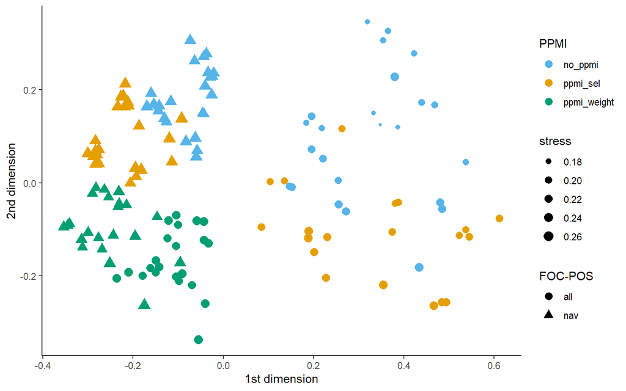

Figure 8. Cloud of models of ‘spot’ colored by `PPMI`. Explore it [here](https://montesmariana.github.io/NephoVis/level1.html?type=spot).

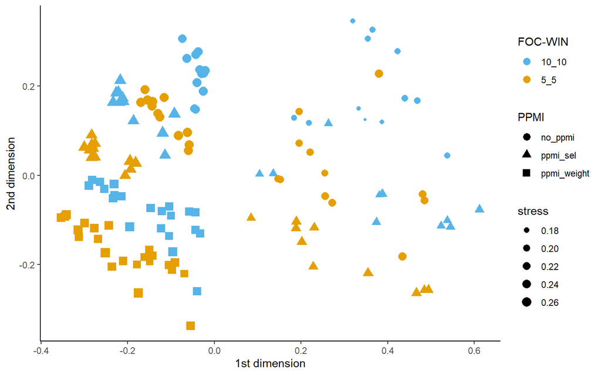

Figure 9. Cloud of models of ‘spot’ colored by `FOC-WIN`. Explore it [here](https://montesmariana.github.io/NephoVis/level1.html?type=spot).

To compare the effect of the stronger models, I will first fix weaker parameters to `SOC-WIN:4 + SOC-POS:nav + LENGTH:FOC`, and initially discard `PPMI:selection`.

The distance matrix between the 8 remaining models suggests a main grouping between `PPMI:weight` and `PPMI:no` models, in the sense that the models of the former tend to be more similar to each other (with distances ranging between 0.21 and 0.41) than the latter (0.40-0.73). The one most different to the rest is the one without any restrictions, and is represented by the MDS with a dense center and some outliers. Models with `FOC-POS:nav` leave out a large number of tokens, and a few more with `PPMI:weight` added. These tokens turn out to be mostly the “magazine” group (tokens with *spot_3* ‘spotlight’ as popular sense and *other_sense* as minority sense, with comments on the line of “probably the name of a magazine”. An example is reproduced in (10).) The models that don’t remove them group them tightly in all solutions, both MDS and t-SNE with any perplexity.

10. Spots *op* tweede Walem moest tegen Broechem in laatste instantie nog James Van Vaerenbergh [^2]

An inspection without color coding shows that non weighted MDS solutions are more sensitive to certain outliers; the t-SNE models tend to show two pockets and a scattered mass, the pockets being small with perplexity 5, one of them growing for perplexity 20, and the scattered mass becoming more scattered with increasing perplexity. With perplexity 50, the pockets are only visible in `PPMI:weight` models and, maybe, in `FOC-POS:nav + FOC-WIN:5` models.

Color coding lets us identify the clear group of *hot spot* tokens, that cluster even in the MDS solutions. The rest of the cloud is clearly split between the homonyms and less clearly between senses, with denser clouds surrounded by some outliers in the `PPMI:no` models. The t-SNE models show a very good split between homonyms even with low perplexity, nicer for `PPMI:weight` models, while the `PPMI:no` ones become too disperse too soon. Perplexity of 50 seems too high, the tokens are too scattered. The big pocket belongs to *spot_1* ‘ridicule’, while the biggest cloud joins the senses of the second homonym. Strangely enough, some tokens of *spot_1* are included in the big cloud (the same in different solutions), so they would be worth a deeper investigation.

Fixing stronger parameters to look at the weaker ones (`FOC-WIN:10 + PPMI:weight + LENGTH:FOC`) gives us very similar clouds. The largest distance between the remaining models is 0.46, and except for the `FOC-POS:nav + SOC-WIN:4`, with a value of 0.34, the distance between models that only diverge in `SOC-POS` is 0.0. With `PPMI:selection`, that distance is even smaller, but the distance between `FOC-POS:nav` models and `FOC-POS:all + SOC-WIN:4` reaches 0.68. If we also set `LENGTH:5000`, those distances rise to 0.88-0.9.

> “spot” seems to offer a good example of the granularity of homonymy versus polysemy, but some cases require further observation. I would choose models with `PPMI:weight + FOC-WIN:10 + SOC-POS:nav + SOC-WIN:4 + LENGTH:FOC | LENGTH:5000`. Selecting the `FOC-POS` would depend on whether we want to model the single “Spot op” tokens or not. This is likely to turn out different without sentence boundaries.

# *staal*

The noun *staal* was tagged with 4 definitions, reproduced in Table 10. The homonyms correspond roughly to “steel” (referring to the material in *staal_1* and to an object made of it in *staal_2*) and “sample” (in a general sense in *staal_3* and with the specific connotation of “evidence” in *staal_4*). Both homonyms are then polysemous, although with very skewed distributions, and *staal_4* was not recorded in the original estimation.

Table 10. Definitions of ‘staal’.

| code | definition | example | freq |
| --- | --- | --- | --- |
| staal_1 | 1.1 zeer hard ijzer met laag koolstofgehalte | twaalf ton staal, ijzer en staal, een man van staal | 21 |
| staal_2 | 1.2 voorwerp of deel van een voorwerp uit zulk metaal | het staal van de velgen is verroest | 3 |
| staal_3 | 2.1 monster van een stof of materiaal, bij wijze van proef | een staal vragen, goederen op staal verkopen | 10 |
| staal_4 | 2.2 proef, voorbeeld, bewijs | een staaltje van hun kunnen, een staaltje van bewaamheid | 0 |

## Sense distribution

The sample consists of 320 tokens (8 batches) out of 5796 occurrences in the QLVLNewsCorpus; the distribution of the majority senses of each batch, as well as my estimate and the overall distribution, are reproduced in Figure 10. The overall distribution resembles the estimation, with a great majority of *staal_1* ‘steel-material’ cases, then *staal_3* ‘sample-general’ and *staal_2* ‘steel-object’. The number of cases without an assigned sense is much smaller, and *staal_4* ‘sample-evidence’ is shown to occur. The distribution does seem to vary a lot between batches. We can say then that:

> “staal” is a noun with two homonyms of very different frequencies, both with different senses of very different frequencies.

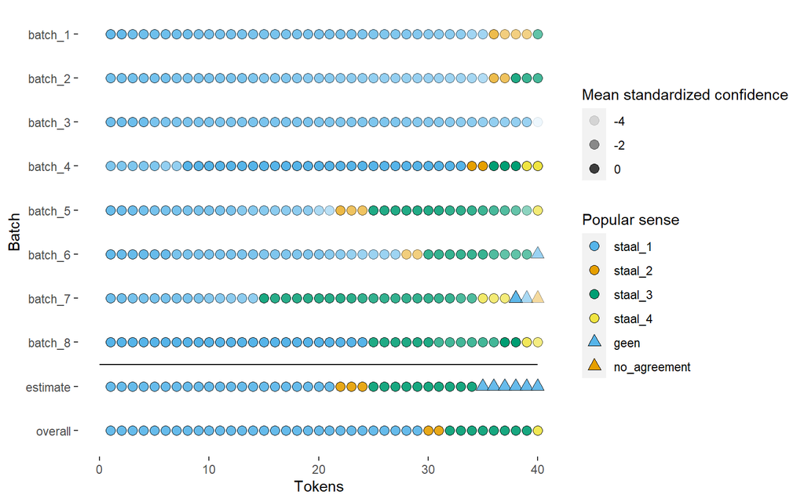

Figure 10. Distribution of majority senses of ‘staal’ per batch

## Confusion matrix

The confusion matrix between the majority senses and other tagged senses can be seen in Table 11 (raw number of tokens with such senses assigned) and Table 12 (mean confidence of such sense annotation in each token).

We expect some confusion between the senses of each homonym, with little or no confusion between homonymous items. That seems indeed to be the case: there is barely any confusion between homonyms, and something between senses of the same homonym, particularly cases where the majority assigned a more general sense (*staal_1* ‘steel-material’ or *staal_3* ‘sample-general’) and a minority the more specific case (*staal_2* ‘steel-object’ or *staal_4* ‘sample-evidence’ respectively), which is to be expected if the context is not very precise. In fact, none of the cases of *staal_4* ‘sample evidence’ shows full agreement, and only 0.38 of *staal_2* ‘steel-object’ does. There are very few cases that couldn’t be assigned any of the given tags; only one where the annotators couldn’t agree.

Table 11. Non weighted sense matrix of ‘staal’ senses. Proportion of tokens with full agreement per sense-tag is: staal_2: 0.38, staal_1: 0.69, staal_3: 0.59, wrong_lemma: 1. Proportion of tokens with full agreement per homonym is: steel: 0.96, sample: 0.93, geen: 0.33.

| senses | steel staal_1 | steel staal_2 | sample staal_3 | sample staal_4 | geen other_sense | geen unclear | geen wrong_lemma | total |
| --- | --- | --- | --- | --- | --- | --- | --- | --- |
| staal_1 | 229 | 62 | 1 | 3 | 4 | 1 | 0 | 229 |
| staal_2 | 7 | 13 | 0 | 0 | 0 | 1 | 0 | 13 |
| staal_3 | 4 | 0 | 66 | 22 | 0 | 1 | 0 | 66 |
| staal_4 | 0 | 0 | 8 | 8 | 0 | 0 | 0 | 8 |
| other_sense | 0 | 0 | 1 | 0 | 1 | 0 | 0 | 1 |
| unclear | 0 | 0 | 1 | 0 | 0 | 1 | 0 | 1 |
| wrong_lemma | 0 | 0 | 0 | 0 | 0 | 0 | 1 | 1 |
| no_agreement | 1 | 0 | 1 | 0 | 0 | 1 | 0 | 1 |
| total | 241 | 75 | 78 | 33 | 5 | 5 | 1 | 0 |

In broad terms, mean confidence seems high in cases of agreement. The cases with *staal_2* ‘steel-object’ as majority sense seem to get a lower confidence, although those with *staal_1* ‘steel-material’ as majority and *staal_2* ‘steel-object’ as minority have a higher mean confidence. On the other hand, both in agreement and disagreement with each other, *staal_3* ‘sample-general’ and *staal_4* ‘sample-evidence’ annotations received a relatively high confidence.

Table 12. Weighted sense matrix of ‘staal’ senses

| senses | staal_1 | staal_2 | staal_3 | staal_4 | other_sense | unclear | wrong_lemma |
| --- | --- | --- | --- | --- | --- | --- | --- |
| staal_1 | 4.02 | 4.05 | 3 | 2.33 | 3.5 | 1 | 0 |
| staal_2 | 3.29 | 3.28 | 0 | 0 | 0 | 1 | 0 |
| staal_3 | 3.5 | 0 | 4.26 | 4.18 | 0 | 3 | 0 |
| staal_4 | 0 | 0 | 4.25 | 4.06 | 0 | 0 | 0 |
| other_sense | 0 | 0 | 3 | 0 | 2 | 0 | 0 |
| unclear | 0 | 0 | 5 | 0 | 0 | 3 | 0 |
| wrong_lemma | 0 | 0 | 0 | 0 | 0 | 0 | 5 |
| no_agreement | 0 | 0 | 3 | 0 | 0 | 0 | 0 |

## Nephology of *staal*

My first impression on the clouds relates to the stress values of the dimensionality reduction and the parameters that make the strongest distinctions between models. We have 144 models of *staal* created on 10/03/2020, modeling between 313 and 319 tokens. The stress value of the MDS solution for the cloud of models is 0.152.

The most dividing parameter is `FOC-WIN`, splitting the cloud of models along the second dimension. Within each half, the most clear divisions are made by `PPMI` (Figure 11), `FOC-POS` and, surprisingly enough, `SOC-WIN`, although that distance is minimal when `FOC-POS:nav` (Figure 12). The stress values of the MDS solutions of these models range between 0.199 and 0.253.

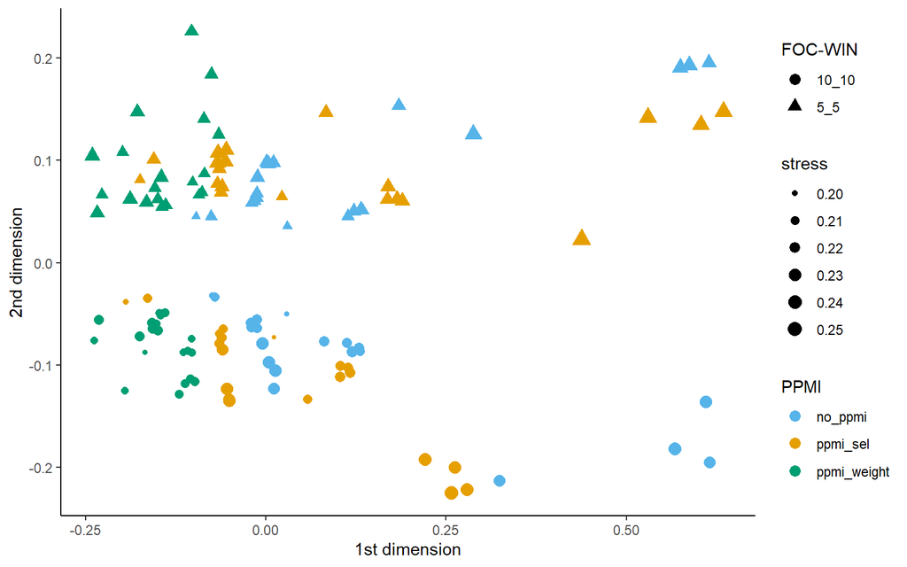

Figure 11. Cloud of models of ‘staal’ colored by `PPMI`. Explore it [here](https://montesmariana.github.io/NephoVis/level1.html?type=staal).

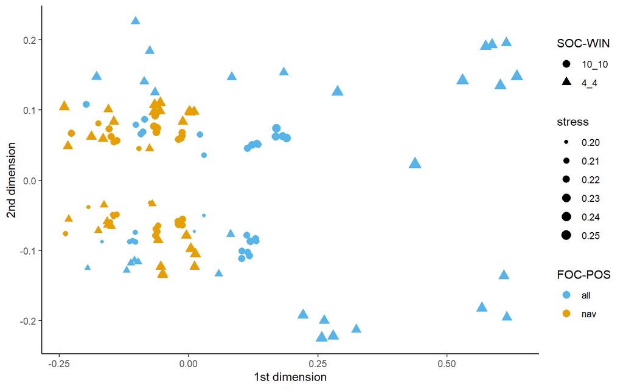

Figure 12. Cloud of models of ‘staal’ colored by `FOC-POS`. Explore it [here](https://montesmariana.github.io/NephoVis/level1.html?type=staal).

To compare the effect of weaker variables, I selected those with `SOC-POS:all + LENGTH:FOC + PPMI:weight | PPMI:no`. I compared the outcomes of different `SOC-WIN` but they didn’t seem that relevant. The distances between the models in each `SOC-WIN` group range between 0.16 and 0.46/0.51. Distance between models that only vary across that parameter go rarely above 0.2.

Few tokens are discarded by restrictive models for this type. Without color coding, we can see that non weighted models tend to have a dense core with some outliers in the MDS solutions, while weighted models are more evenly dispersed; in the t-SNE models, some reasonable clusters begin to show with perplexity of 20, taking a nicer shape with perplexity of 30 for the weighted models and somewhat less interesting with perplexity of 50.

> “staal” seems to model the distinction between homonyms neatly, but has a hard time identifying the senses of the annotation. The models do offer other clusters that I would like to inspect and define. Because of the shape of the subclouds and the variety between the options, I would like to further inspect cases of `FOC-WIN:10 + FOC-POS:nav + PPMI:weight + SOC-POS:nav` to look into the difference between `LENGTH` and `SOC-WIN` values.

# *stof*

Table 13. Definitions of ‘stof’.

| code | definition | example | freq |
| --- | --- | --- | --- |
| stof_1 | 1.1 materie, substantie van een bepaald type | giftige stoffen, vaste stof, grijze stof | 15 |
| stof_2 | 1.2 weefsel | wollen en katoenen stoffen | 11 |
| stof_3 | 1.3 onderwerp waarover men spreekt, schrijft, nadenkt etc. | stof voor een roman, stof tot onenigheid | 4 |
| stof_4 | 2.1 massa zeer kleine droge deeltjes van verschillende oorsprong, door de lucht meegevoerd | een wolk stof, stof afnemen | 2 |
| stof_5 | 2.2 massa zeer kleine deeltjes als toestand van een specifieke substantie | iets tot stof vermalen, tot stof verpulveren | 8 |

## Sense distribution

The sample consists of 320 tokens (8 batches) out of 24502 occurrences in the QLVLNewsCorpus; the distribution of the majority senses of each batch, as well as my estimate and the overall distribution, are reproduced in Figure 13.

The overall frequency is quite similar to the expected one, except that the *stof_4* ‘dust’ sense was tagged much more frequently than *stof_5* ‘powder’, contrary to what I did in my pilot sample. That said, it is also very clear that the mean confidence of those tokens is quite low. There is also a small number of cases that seemed particularly challenging to annotate.

> “stof” is a noun with two homonyms of different frequencies, both polysemous, the most frequent having one frequent sense and two less frequent ones, and the infrequent one having two senses with a skewed distribution.

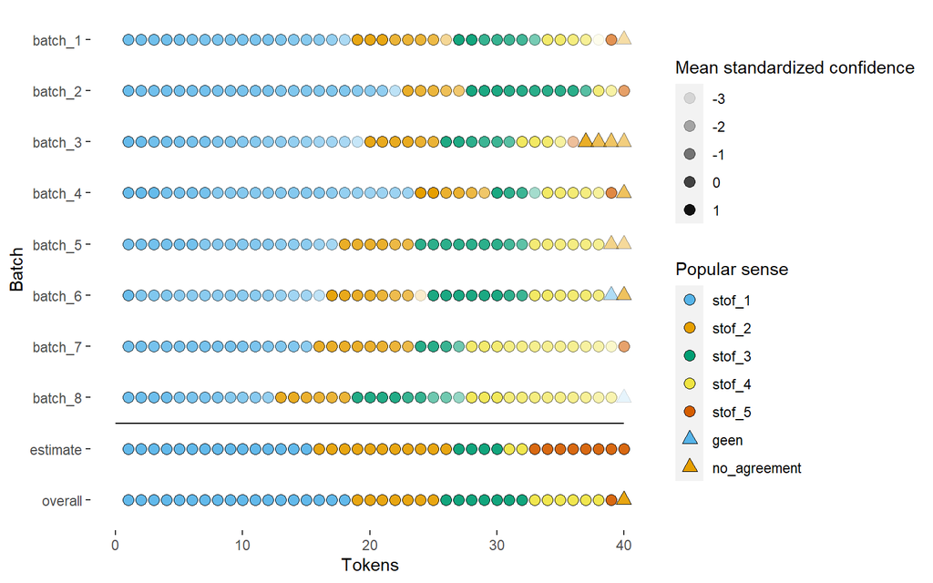

Figure 13. Distribution of majority senses of ‘stof’ per batch

## Confusion matrix

The confusion matrix between the majority senses and other tagged senses can be seen in Table 14 (raw number of tokens with such senses assigned) and Table 15 (mean confidence of such sense annotation in each token).

We would expect quite some confusion between the two senses of the “dust” homonym (*stof_4* and *stof_5*), more than between the senses of the first homonym, but also some confusion between *stof_1* ‘substance’ the “dust” senses could be acceptable. Still, the annotators were made aware of a distinction made between the homonyms (through the numbers of the definitions… assuming they did pay attention to them), so they might be more careful about the difference between them.

In general terms, there is indeed little overlap between the senses. There are more annotations of the “dust” senses in cases with *stof_1* ‘substance’ as majority than of other senses. However, there is also an unexpectedly high number of cases where the majority assigned *stof_3* ‘topic’ and a minority assigned one of the “dust” senses. These are mostly instances of figurative expressions such as *het stof doen opwaaien*, where there is a predominat “topic” theme. There is also a relatively high number of cases without any agreement between annotators, some of which are also idiomatic expressions (*door het stof gaan* or *het stof doen opwaaien*).

Table 14. Non weighted sense matrix of ‘stof’ senses. Proportion of tokens with full agreement per sense-tag is: stof_1: 0.89, stof_2: 0.85, stof_3: 0.65, stof_4: 0.54. Proportion of tokens with full agreement per homonym is: substance: 0.86, dust: 0.69.

| senses | substance stof_1 | substance stof_2 | substance stof_3 | dust stof_4 | dust stof_5 | geen other_sense | geen unclear | total |
| --- | --- | --- | --- | --- | --- | --- | --- | --- |
| stof_1 | 142 | 2 | 0 | 7 | 6 | 1 | 0 | 142 |
| stof_2 | 4 | 53 | 3 | 2 | 0 | 0 | 0 | 53 |
| stof_3 | 1 | 2 | 57 | 12 | 2 | 3 | 2 | 57 |
| stof_4 | 1 | 2 | 9 | 52 | 11 | 1 | 2 | 52 |
| stof_5 | 2 | 1 | 0 | 3 | 5 | 0 | 0 | 5 |
| unclear | 0 | 0 | 0 | 2 | 0 | 0 | 2 | 2 |
| no_agreement | 2 | 1 | 6 | 7 | 3 | 5 | 3 | 9 |
| total | 152 | 61 | 75 | 85 | 27 | 10 | 9 | 0 |

While for the senses of the first homonym the confidence levels seem to be high (even when assigning to a case where the majority sense is from the other homonym), those of the second one tend to be rather low. The doubtfulness comes probably from trying to choose between the subtly different senses of “dust”, rather than from distinguishing between homonyms.

Table 15. Weighted sense matrix of ‘stof’ senses

| senses | stof_1 | stof_2 | stof_3 | stof_4 | stof_5 | other_sense | unclear |
| --- | --- | --- | --- | --- | --- | --- | --- |
| stof_1 | 4.26 | 4.5 | 0 | 2.5 | 3.17 | 3 | 0 |
| stof_2 | 3.5 | 4.48 | 5 | 2.5 | 0 | 0 | 0 |
| stof_3 | 4 | 2 | 4.47 | 3.75 | 4 | 2.33 | 0 |
| stof_4 | 4 | 4.5 | 3.11 | 3.89 | 3.09 | 0 | 0 |
| stof_5 | 3 | 5 | 0 | 2.67 | 3.2 | 0 | 0 |
| unclear | 0 | 0 | 0 | 3.5 | 0 | 0 | 1.75 |
| no_agreement | 3 | 4 | 3.17 | 3.71 | 3.67 | 3.6 | 2.33 |

## Nephology of *stof*

My first impression on the clouds relates to the stress values of the dimensionality reduction and the parameters that make the strongest distinctions between models. We have 144 models of *stof* created on 10/03/2020, modeling between 314 and 320 tokens. The stress value of the MDS solution for the cloud of models is 0.158.

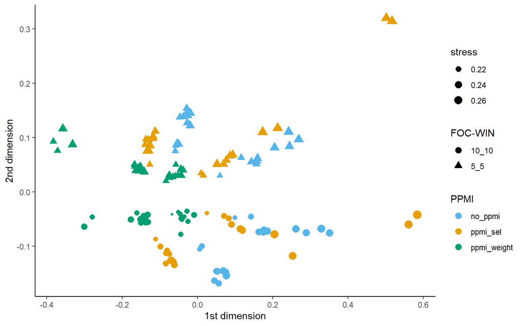

Figure 14. Cloud of models of ‘stof’ colored by weighting. Explore it [here](https://montesmariana.github.io/NephoVis/level1.html?type=stof).

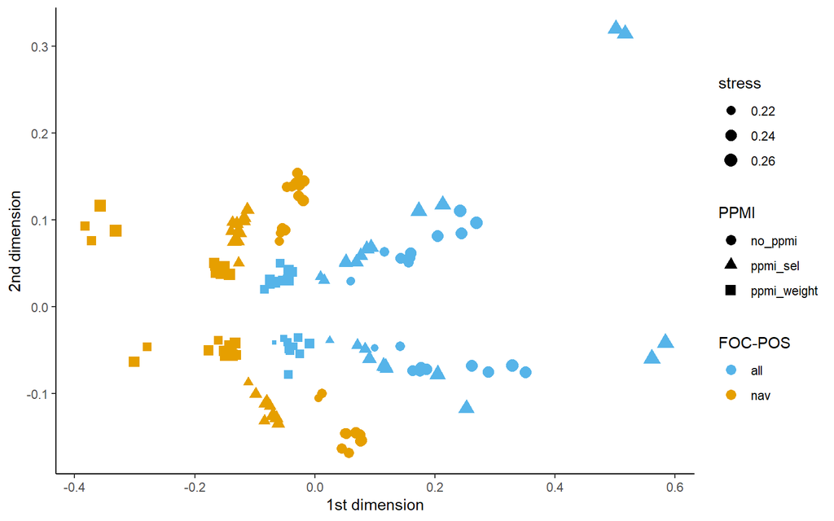

To compare the effect of the stronger parameters I’ll first fix the weaker ones to `SOC-POS:nav + SOC-WIN:4 + LENGTH:FOC`, initially discarding the `PPMI:selection` (when I later compared, it did give results somewhere between the other two). In the resulting selection of models we can see that very few tokens are lost by the restrictions (only 1 with `FOC-POS:nav + FOC-WIN:5`; 3 with `FOC-POS:nav + PPMI:weight` and 6 with all three restrictions). The distances in the distance matrix range between 0.2 (between models with `FOC-POS:all + PPMI:weight`, followed by 0.23 for models with `FOC-POS:all + PPMI:no`) and 0.77 (between the strictest and the weakest restrictions). The strictest model is the one most different to all the rest.

Without color coding, we can see that MDS solutions with `PPMI:no` tend to have a dense core with some outliers (rather like satellites) and that neat clusters start to form with perplexity of 20 for the t-SNE solutions. There is one particular small ball in the periphery, especially in the `PPMI:weight` models, and two big subclouds, especially in the `FOC-POS:nav` models. This structure becomes much clearer with perplexity 30, but raising it to 50 merges those big subclouds and hides the small ball in the `PPMI:no` models.

Color coding lets us see that homonyms seem to group together in MDS solutions, but rather spread around and with a lot of overlap; senses also seem to group together but with big overlap, and *stof_5* ‘powder’ is quite disperse in `PPMI:no` models. In t-SNE models, there is no clear division of homonyms for perplexity of 5 but it does become clear when it’s 20. The little ball, persistent across all models, has tokens of different senses, but that is an artifact of the annotators’ confusion, since those tokens clearly correspond to the idiom “de stof doen opwaaien”. From perplexity 30, one of the big clouds belongs to *stof_1* ‘substance’, while the other one is split between *stof_2* ‘fabric’ and *stof_4* ‘dust’ and there’s a smaller, less compact one for *stof_3* ‘topic’. Perplexity 50 does not improve the stucture; only for `FOC-POS:nav` models does it stay relatively clear.

To look at the variation between weaker parameters, I fixed the strongest one to a combination that already seems to work out fine: `FOC-POS:nav + PPMI:weight + FOC-WIN:10` (a stricter `FOC-WIN` doesn’t seem to improve the results). I also disregarded `LENGTH:10000`. The distance matrix between the models in the resulting selection has values ranging from 0.07 (between the `SOC-POS:nav + LENGTH:5000` models) and 0.49 (between the `SOC-POS:nav + SOC-WIN:4 + LENGTH:FOC` and the `SOC-POS:all + SOC-WIN:4 + LENGTH:5000` models). The model with `SOC-POS:nav + SOC-WIN:4 + LENGTH:FOC` is the most different to the rest and the one I like the most. The models with `LENGTH:FOC` keep the *stof_3* ‘topic’ cluster clear away from the rest, while `LENGTH:5000` leaves it more disperse and closer to the bigger masses. I checked the previous combination of fixed weak parameters, replacing `LENGTH:FOC` with `LENGTH:5000`, and the results were indeed less structured than the ones I described, to the point where `PPMI:no` t-SNE models quickly merged into one cluster.

> The “stof” models don’t seem too bad at identifying homonyms but they do combine two senses of different homonyms into a cluster, so I would like to look into that. They also successfully identify an idiomatic expression. For further inspection I would select models with `FOC-POS:nav + PPMI:weight + LENGTH:FOC + SOC-POS:nav + SOC-WIN:4`.

# *schaal*

The noun *schaal* was tagged with 6 definitions, reproduced in Table 16. Both homonyms are polysemous but have very different frequencies. The first one, roughly equivalent to (abstract) “scale”, is estimated to present mostly the “on big scale” sense (*schaal_3*) and fewer cases of specific scales, either precising the relation between sizes (*schaal_2*) or with a name or range (*schaal_1*). The second, infrequent homonym was mostly registered in the sense of “dish” (*schaal_5*) but could also occur with the “shell” (*schaal_4*) or the “scale-dish” (*schaal_6*) senses.

Table 16. Definitions of ‘schaal’.

| code | definition | example | freq |
| --- | --- | --- | --- |
| schaal_1 | 1.1 een geordende reeks cijfers, afstanden, hoeveelheden e.d. waarmee iets gemeten wordt | de schaal van Celsius, Richter, op een schaal van 1 tot 5 | 0 |
| schaal_2 | 1.2 de verhouding tussen de grootte van iets en de weergave ervan in een kaart, model, grafiek etc. | een schaal van 1:20, een schaal van 10 km | 6 |
| schaal_3 | 1.3 grootteorde, omvang | de schaal van een probleem, op grote/kleine schaal | 24 |
| schaal_4 | 2.1 harde buitenbekleding van zekere organische zaken | de schaal van een ei, de schalen van een mossel | 0 |
| schaal_5 | 2.2 ondiepe en wijde schotel | een schaal met vruchten | 4 |
| schaal_6 | 2.3 elk van de beide schotels die aan de armen van een balans hangen | gewicht in de schaal leggen | 0 |

## Sense distribution

The sample consists of 320 tokens (8 batches) out of 14249 occurrences in the QLVLNewsCorpus; the distribution of the majority senses of each batch, as well as my estimate and the overall distribution, are reproduced in Figure 16.

The overall distribution resembles indeed the estimate, adding some presence of the senses *schaal_1* ‘scale-range’ (not distinguished from *schaal_2* ‘scale-transformation- in the pilot sample) and *schaal_6* ’dish-scale’. *schaal_4* ‘shell’ would seem to occur only once in the whole concordance.

> “schaal” is a noun with two homonyms of different frequencies, both polysemous with senses of different frequencies.

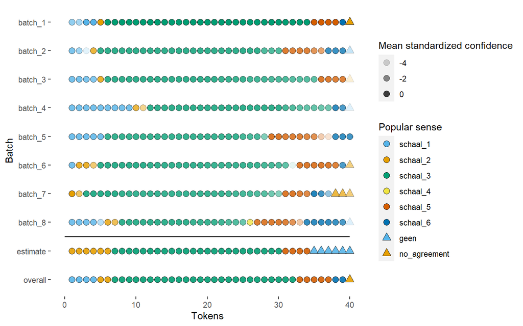

Figure 16. Distribution of majority senses of ‘schaal’ per batch

## Confusion matrix

The confusion matrix between the majority senses and other tagged senses can be seen in Table 17 (raw number of tokens with such senses assigned) and Table 18 (mean confidence of such sense annotation in each token).

We would expect no confusion between tokens of different homonyms, but disagreement between the senses within each homonym would be acceptable. Confusion in the “dish” set of senses could be attributed to unclear or unspecified contexts, while that between “scale” senses could also be due to a lack of understanding of the differences between them.

Table 17. Non weighted sense matrix of ‘schaal’ senses. Proportion of tokens with full agreement per sense-tag is: schaal_3: 0.93, schaal_1: 0.9, schaal_5: 0.92, schaal_2: 0.75, schaal_6: 0.79, unclear: 0.33, schaal_4: 1. Proportion of tokens with full agreement per homonym is: scale: 0.98, dish: 0.9, geen: 0.2.

| senses | scale schaal_1 | scale schaal_2 | scale schaal_3 | dish schaal_4 | dish schaal_5 | dish schaal_6 | geen between | geen other_sense | geen unclear | total |
| --- | --- | --- | --- | --- | --- | --- | --- | --- | --- | --- |
| schaal_1 | 31 | 0 | 3 | 0 | 0 | 0 | 0 | 0 | 0 | 31 |
| schaal_2 | 1 | 12 | 2 | 0 | 0 | 0 | 0 | 0 | 0 | 12 |
| schaal_3 | 8 | 3 | 208 | 0 | 0 | 1 | 2 | 1 | 0 | 208 |
| schaal_4 | 0 | 0 | 0 | 1 | 0 | 0 | 0 | 0 | 0 | 1 |
| schaal_5 | 0 | 0 | 1 | 0 | 40 | 1 | 1 | 0 | 0 | 40 |
| schaal_6 | 0 | 0 | 1 | 0 | 1 | 19 | 0 | 2 | 0 | 19 |
| unclear | 0 | 0 | 1 | 0 | 1 | 0 | 0 | 0 | 3 | 3 |
| no_agreement | 4 | 2 | 4 | 0 | 1 | 2 | 0 | 2 | 3 | 6 |
| total | 44 | 17 | 220 | 1 | 43 | 23 | 3 | 5 | 6 | 0 |

We find indeed very little overlap, either between senses of the same homonym or between *schaal_3* ‘scale-main’ the “dish” senses. The *schaal_3* ‘scale-main’ tokens that were assigned senses from another homonym are reproduced in (11) through (13): (11) received the *schaal_6* ‘dish-scale’ tag, and (12) and (13) received the *between* tag with the explanation that both *schaal_1* ‘scale-range’ and *schaal_3* ‘scale-main’ could be appropriate. (14) shows the token with *schaal_5* ‘dish’ as majority sense and *schaal_3* ‘scale-main’ as minority sense. The other overlapping instances are not so interesting.

11. crimineel wapengebruik . Juist daarom vreest Geoffrey Bindman , een vooraanstaand mensenrechtenactivist , een glijdende schaal : De bewapening van agenten om criminaliteit de kop in te drukken is iets
12. het feest van de hoogst individuele expressie en de behoefte aan authenticiteit . En de schaal van de menselijke maat wordt opnieuw uitgevonden . Waar anders dan in het woninginterieur wordt
13. verscheen tien jaar geleden de westerse wasmachine . Kijk , dat is globalisering op menselijke schaal . Een ouderwetse bak nog , die je met water vult , waarin je zeep
14. Feyenoord dit seizoen niets . Geen beker , geen titel . PSV krijgt straks de schaal die hoort bij de kampioen van Nederland . De verklaring voor het Brabantse succes is

Overall, the agreeing annotations have a rather high confidence. There are still some disagreeing ones with high confidence, which could be due to the annotators’ tendency, given that it was only one in each case. The single “shell” annotation, which seemed unproblematic (only filled cell in the corresponding row and column), somehow didn’t receive the highest confidence from all annotators.

Table 18. Weighted sense matrix of ‘schaal’ senses

| senses | schaal_1 | schaal_2 | schaal_3 | schaal_4 | schaal_5 | schaal_6 | between | other_sense | unclear |
| --- | --- | --- | --- | --- | --- | --- | --- | --- | --- |
| schaal_1 | 4.51 | 0 | 4.67 | 0 | 0 | 0 | 0 | 0 | 0 |
| schaal_2 | 5 | 4.42 | 2.5 | 0 | 0 | 0 | 0 | 0 | 0 |
| schaal_3 | 3.75 | 3.67 | 4.56 | 0 | 0 | 3 | 2.5 | 2 | 0 |
| schaal_4 | 0 | 0 | 0 | 4.75 | 0 | 0 | 0 | 0 | 0 |
| schaal_5 | 0 | 0 | 1 | 0 | 4.5 | 4 | 2 | 0 | 0 |
| schaal_6 | 0 | 0 | 5 | 0 | 5 | 4.51 | 0 | 4 | 0 |
| unclear | 0 | 0 | 4 | 0 | 5 | 0 | 0 | 0 | 1.39 |
| no_agreement | 3 | 3.5 | 3.75 | 0 | 4 | 1.5 | 0 | 1.5 | 3.33 |

## Nephology of *schaal*

My first impression on the clouds relates to the stress values of the dimensionality reduction and the parameters that make the strongest distinctions between models. We have 144 models of *schaal* created on 10/03/2020, modeling between 308 and 320 tokens. The stress value of the MDS solution for the cloud of models is 0.121.

The subclouds of the cloud of models are less distinct than for other lemmas, but color coding does show important groupings, with `FOC-POS:all + PPMI:selection | PPMI:no` on the right side, `PPMI:weight` on the top left quadrant and `FOC-POS:nav + PPMI:selection | PPMI:no` on the bottom left quadrant, more or less, closer to the `PPMI:weight` area than to the `FOC-POS:all` area (Figure 17). Both `SOC-WIN` and `FOC-WIN` seem to group models as well, the former pushing `SOC-WIN:10` models to the inside and `SOC-WIN:4` to the outside (Figure 18), the latter splitting the three main areas separately. The stress values of the MDS solutions of these models range between 0.192 and 0.263.

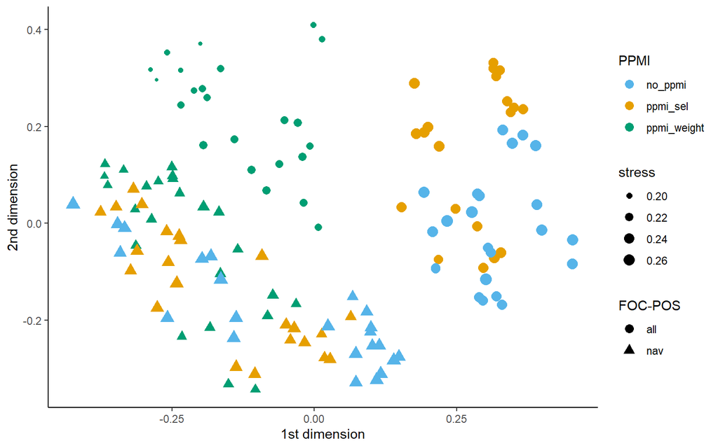

Figure 17. Cloud of models of ‘schaal’ colored by `PPMI`. Explore it [here](https://montesmariana.github.io/NephoVis/level1.html?type=schaal).

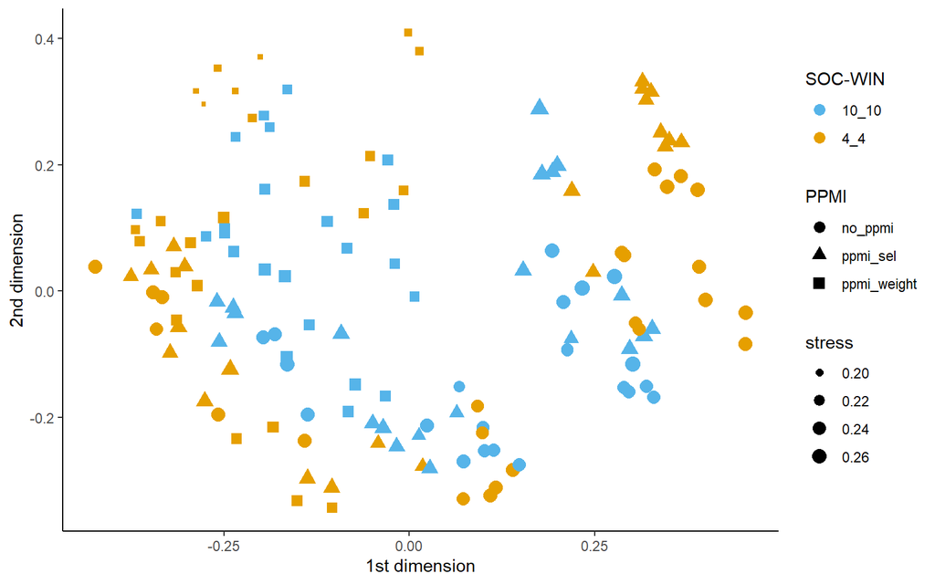

Figure 18. Cloud of models of ‘schaal’ colored by `SOC-WIN`. Explore it [here](https://montesmariana.github.io/NephoVis/level1.html?type=schaal).

In order to compare the effects of the strongest parameters, I selected clouds with `SOC-POS:nav + LENGTH:FOC + PPMI:weight | PPMI:no`. I compared sets with different `SOC-WIN` separately and, while there are some differences (particularly under certain conditions), I cannot decide which one works better yet.

These models don’t exclude so many tokens: 4 with `FOC-POS:nav + FOC-WIN:5`, 6 with `FOC-POS:nav + PPMI:weight` and 12 with all three restrictions. In the distance matrix between these models, the highest value is between the strictest and the least strict model (0.72 with `SOC-WIN:10`, 0.75 with `SOC-WIN:4`). With `SOC-WIN:10`, `FOC-WIN:5` makes for a bigger difference between models that differn in `PPMI` (0.65-0.7), but not so much when they differ in `FOC-POS`. With `SOC-WIN:4`, instead, the distance matrix individuates the `FOC-POS:all + PPMI:no` models as the most different to the rest, as well as one of the pairs of lowest similarity, with 0.35.

The MDS solutions seem to be more disperse (or less concentrated) with `PPMI:weight`, showing one big cloud with some satellites and even a smaller cloud close by (or two, for `FOC-WIN:10 + PPMI:weight` models). The smaller cloud is mostly made of tokens from the second homonym “dish”.

The t-SNE solutions show three small clusters around a mass that turns from an archipelago with perplexity 5 to a more compact mass with perplexity 20 and a more disperse one with perplexity 50. I don’t see much difference between the solutions with perplexity 20 and 30. The three small clusters correspond quite well to tokens annotated with *schaal_1* ‘scale-range’, *schaal_5* ‘dish’ and *schaal_6* ‘dish-scale’. The three senses do cluster quite neatly even in the MDS solution. Furthermore, `PPMI:weight` models show a small cluster of tokens with some variant of “op kleine schaal”; this group is rather firm but not complete in `PPMI:selection + LENGTH:FOC` models and disperse or at least swallowed by the bigger *schaal_3* ‘scale-main’ cloud (is that so bad? It’s not really a fixed expression distinct from the rest of the that sense).

A main difference between models with different `FOC-POS` for this lemma is whether they make use of prepositions such as *op* and *in*. On the one hand, they do characterize certain usages. On the other, they are very frequent in the sample (particularly *op*) so they are not necessarily distinctive. In any case, `FOC-POS:nav` cases do not perform worse than the `FOC-POS:all` counterparts, relying mostly on adjectives.

Finally, I made another selection with `FOC-WIN:10 + FOC-POS:nav + SOC-POS:nav`, fixing also first `LENGTH:FOC` and then `LENGTH:5000`, to compare the effects of all three `PPMI` values and `SOC-WIN`. I only looked at the distance matrix and the t-SNE solutions with perplexity of 30 (I didn’t get any further insight from looking at the MDS solutions). One observation is that all models retain the three small clusters and that the main *schaal_3* ‘scale-main’ cloud is more elongated with `PPMI:weight` and seems to have some pockets with `PPMI:selection`. In the distance matrix, `SOC-WIN` makes the biggest difference between `PPMI:selection` models and the smallest between `PPMI:no` models. With `LENGTH:5000`. the main cloud is always more disperse and `SOC-WIN` makes a bigger difference: from 0.24 between `PPMI:no` models and 0.5 between `PPMI:weight` models. The difference between `PPMI:weight` and `PPMI:no` models is also bigger in this case; the latter gives much more disperse points.

> “schaal” shows a suprisingly good division between homonyms and senses, regardless of their frequencies, and while `PPMI:weight` seems better at picking up a collocation that is not so relevant, all clouds seem to perform similarly. For further inspection I would choose `FOC-WIN:10 + PPMI:selection | PPMI:weight + LENGTH:FOC + SOC-WIN:4 + SOC-POS:nav`. I think this is a particularly fruitful case to understand the role of prepositions.

# *blik*

The noun *blik* was tagged with 6 definitions, reproduced in Table 19. The homonyms are both polysemous, with a more clear polysemy in the most frequent one (and roughly equally frequent senses) and a more subtle metonymy (conceptually not challenging, but strongly dependent on the clarity of the context) for the other. The former corresponds to English “gaze/look”, with separate senses for physically looking at something (*blik_1*), the (eyes-focused) facial expression (*blik_2*) and metaphorical, intellectual look (*blik_3*). The latter means “tin” and could refer to the material itself (*blik_4*), an object (like a tin can, *blik_5*) or canned food (*blik_6*). In my pilot sample I didn’t find instances of *blik_6* and found it hard to distinguish between the other senses of “tin”, particularly given the frequency of this homonym relative to the other one.

Table 19. Definitions of ‘blik’.

| code | definition | example | freq |
| --- | --- | --- | --- |
| blik_1 | 1.1 oogopslag | een blik werpen op iets, een blik van verstandhouding | 10 |
| blik_2 | 1.2 gezichtsvermogen | een scherpe blik | 12 |
| blik_3 | 1.3 inzicht, in intellectuele zin | een brede blik | 11 |
| blik_4 | 2.1 dun geplet metaal, i.h. bijz. vertind dun plaatstaal | dozen uit blik | 6 |
| blik_5 | 2.2 voorwerp (i.h.bijz. doos voor voedsel) vervaardigd uit zulk materiaal | stoffer en blik, een blik erwtjes, een maaltijd uit blik | 0 |
| blik_6 | 2.3 voedsel bewaard in een voorwerp als bedoeld in 2.2 | eet je niet teveel blik? | 0 |

## Sense distribution

The sample consists of 280 tokens (7 batches) out of 22175 occurrences in the QLVLNewsCorpus; the distribution of the majority senses of each batch, as well as my estimate and the overall distribution, are reproduced in Figure 19.

> “blik” is a noun with two homonyms of different frequencies, each with three senses and skewed frequencies.

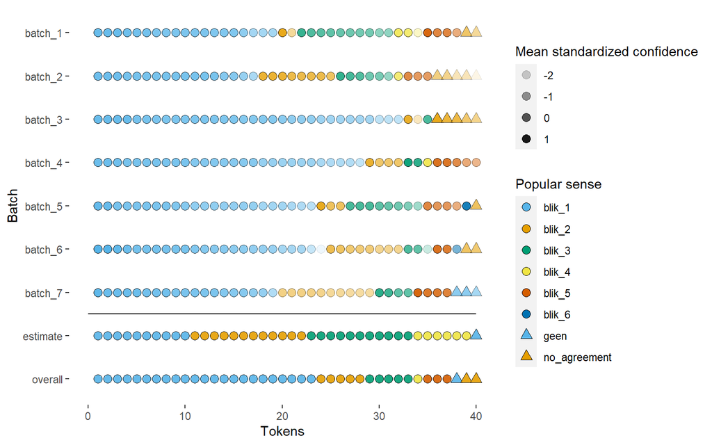

Figure 19. Distribution of majority senses of ‘blik’ per batch

## Confusion matrix

The confusion matrix between the majority senses and other tagged senses can be seen in Table 20 (raw number of tokens with such senses assigned) and Table 21 (mean confidence of such sense annotation in each token).

We would expect no confusion at all between the homonyms, and probably more confusion between “tin” senses than between “look” senses. Indeed, there is only one case in which most annotators chose *blik_3* ‘look-intellectual’ and one tagged *blik_4* ‘tin-material’ but otherwise most of the disagreement pertains *geen* ‘none of the above’ tags. As we can see in Table 21, the confidence of that annotation is low (I checked: also for the other annotators in the same token). The example is copied in (15) and proves interesting one to look for in the cloud, given the potential context words in different models.

15. door één en dezelfde fotograaf . Stuk voor stuk zijn ze gemaakt met eenzelfde sobere **blik** die tegelijkertijd afstandelijk en inlevend is . Alles op die foto’s is bedoeld om in

There is a high number (5%) of tokens where not two annotators could agree, but a closer inspection to the annotations reveals that the disagreement tends to be between the three different senses of the first homonym (and sometimes between *blik_4* ‘tin-material’, *blik_5* ‘tin-object’ and *unclear* or *between*), so collapsing the homonyms would get rid off the disagreement. On the other hand, the disagreement within the “look” homonym is surprisingly high, especially between *blik_1* ‘look’ and *blik_2* ‘look-expression’ (which are a matter of perspective and might, indeed, be hard to discriminate in certain contexts). This is particularly revealing when looking a the mean confidence values, which are overall quite low. At the homonym level, however, the proportion of tokens with full agreement is very high in both cases.

Table 20. Non weighted sense matrix of ‘blik’ senses. Proportion of tokens with full agreement per sense-tag is: blik_3: 0.44, blik_5: 0.68, blik_1: 0.52, blik_4: 0.6, blik_2: 0.22. Proportion of tokens with full agreement per homonym is: gaze: 0.98, tin: 0.94.

| senses | gaze blik_1 | gaze blik_2 | gaze blik_3 | tin blik_4 | tin blik_5 | tin blik_6 | geen between | geen other_sense | geen unclear | geen wrong_lemma | total |
| --- | --- | --- | --- | --- | --- | --- | --- | --- | --- | --- | --- |
| blik_1 | 162 | 56 | 21 | 0 | 0 | 0 | 1 | 0 | 0 | 0 | 162 |
| blik_2 | 27 | 37 | 1 | 0 | 0 | 0 | 0 | 1 | 0 | 0 | 37 |
| blik_3 | 13 | 5 | 34 | 1 | 0 | 0 | 0 | 0 | 0 | 0 | 34 |
| blik_4 | 0 | 0 | 0 | 5 | 2 | 0 | 0 | 0 | 0 | 0 | 5 |
| blik_5 | 0 | 0 | 0 | 5 | 22 | 2 | 0 | 0 | 0 | 0 | 22 |
| blik_6 | 0 | 0 | 0 | 1 | 1 | 2 | 0 | 0 | 0 | 0 | 2 |
| other_sense | 0 | 1 | 0 | 0 | 0 | 0 | 0 | 1 | 0 | 0 | 1 |
| unclear | 1 | 0 | 0 | 0 | 0 | 0 | 0 | 0 | 1 | 0 | 1 |
| wrong_lemma | 1 | 0 | 0 | 0 | 0 | 0 | 0 | 0 | 0 | 1 | 1 |
| no_agreement | 12 | 12 | 11 | 2 | 3 | 0 | 0 | 2 | 3 | 0 | 15 |
| total | 216 | 111 | 67 | 14 | 28 | 4 | 1 | 4 | 4 | 1 | 0 |

Table 21. Weighted sense matrix of ‘blik’ senses

| senses | blik_1 | blik_2 | blik_3 | blik_4 | blik_5 | blik_6 | between | other_sense | unclear | wrong_lemma |
| --- | --- | --- | --- | --- | --- | --- | --- | --- | --- | --- |
| blik_1 | 4.01 | 3.62 | 2.76 | 0 | 0 | 0 | 0 | 0 | 0 | 0 |
| blik_2 | 3.93 | 3.18 | 4 | 0 | 0 | 0 | 0 | 3 | 0 | 0 |
| blik_3 | 3.77 | 2.8 | 3.68 | 3 | 0 | 0 | 0 | 0 | 0 | 0 |
| blik_4 | 0 | 0 | 0 | 4.13 | 3 | 0 | 0 | 0 | 0 | 0 |
| blik_5 | 0 | 0 | 0 | 3 | 4.2 | 5 | 0 | 0 | 0 | 0 |
| blik_6 | 0 | 0 | 0 | 4 | 5 | 3.5 | 0 | 0 | 0 | 0 |
| other_sense | 0 | 3 | 0 | 0 | 0 | 0 | 0 | 2.5 | 0 | 0 |
| unclear | 3 | 0 | 0 | 0 | 0 | 0 | 0 | 0 | 3.5 | 0 |
| wrong_lemma | 4 | 0 | 0 | 0 | 0 | 0 | 0 | 0 | 0 | 3.5 |
| no_agreement | 3.75 | 3.58 | 3.36 | 2.5 | 2.67 | 0 | 0 | 0 | 1.67 | 0 |

## Nephology of *blik*

My first impression on the clouds relates to the stress values of the dimensionality reduction and the parameters that make the strongest distinctions between models. We have 144 models of *blik* created on 11/03/2020, modeling between 261 and 280 tokens. The stress value of the MDS solution for the cloud of models is 0.148.

The main groups in the cloud of models come from an interaction between `FOC-POS` and `PPMI`, with `FOC-POS:all + PPMI:selection | PPMI:no` on the right side, `FOC-POS:all + PPMI:weight` in the middle and `FOC-POS:nav` on the left side, inside which `PPMI:no` is distinct from `PPMI:weight | PPMI:selection` (Figure 20). The `FOC-POS:all + PPMI:selection | PPMI:no` group is split by `PPMI` along the vertical axis and by `SOC-WIN` along the horizontal one; some `FOC-WIN:10` groups can be found within each `PPMI:no` group as well as a `LENGTH:FOC` one within each `PPMI:weight` group (Figure 21). The stress values of the MDS solutions of these models range between 0.191 and 0.296.

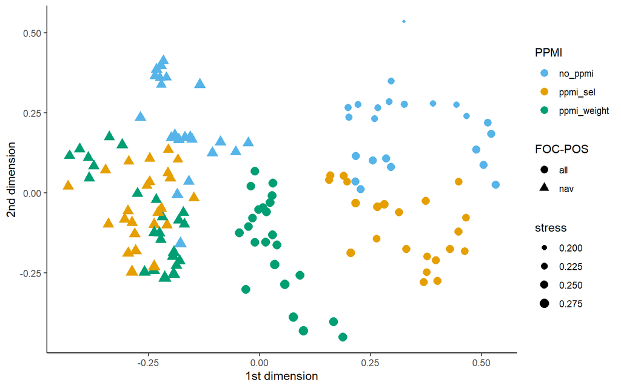

Figure 20. Cloud of models of ‘blik’ colored by `PPMI`. Explore it [here](https://montesmariana.github.io/NephoVis/level1.html?type=blik).

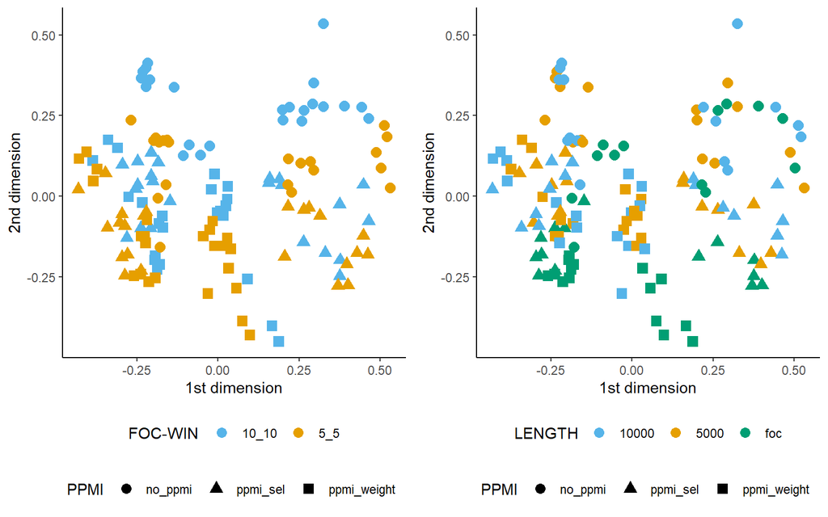

Figure 21. Cloud of models of ‘blik’ colored by `FOC-WIN` (left) and `LENGTH` (right). Explore it [here](https://montesmariana.github.io/NephoVis/level1.html?type=blik).

By inspecting the distance matrix with different combinations of parameters, there would seem to be an interaction between `LENGTH`, `SOC-WIN` and `FOC-WIN`: with `LENGTH:5000`, the difference between models varying only across `SOC-WIN` or `FOC-WIN` depends on the value of the other parameter and `FOC-WIN` settings seem to matter more than `SOC-WIN`, while with `LENGTH:FOC` the values seem more independent and equally distinctive.[^3] Therefore, to compare stronger models I would set `SOC-POS:nav + LENGTH:FOC + PPMI:weight | PPMI:no + SOC-WIN:4` but then check the robustness of the descriptions with `SOC-WIN:10` and with `LENGTH:5000`.

The distance matrix between the selected models shows relatively high values, the smallest being 0.35 (between `FOC-POS:all + PPMI:weight` models) and the largest 0.94 (between `FOC-WIN:10 + FOC-POS:nav + PPMI:weight` on the one hand and the `FOC-POS:all + PPMI:no` models on the other, which present the largest values overall and a distance of 0.48 between each other).

The MDS solutions show two outliers to which the `PPMI:no` models (and especially the least strict model) are quite sensitive, so that all other tokens are joined together in the center and far away from them. `PPMI:selection` models are much less sensitive. Their concordances are reproduced and discussed in the outliers subsection. They don’t stand out in the t-SNE solutions, although one of them seems to tend to the periphery.

The t-SNE solutions start presenting some clusters with perplexity 20, but `PPMI:no` models are then just uniform masses. The clusters are more clear with perplexity 30 but still part of the bigger, disperse cloud, and only `PPMI:weight + FOC-POS:nav + FOC-WIN:5` still has some of that structure with perplexity 50.

The “tin” homonym does tend to group in all solutions, particularly in `PPMI:weight` models, but even t-SNE solutions don’t set it apart so clearly. The same goes for *blik_2* ‘look-expression’ and *blik_3* ‘look-intellectual’, which take special areas in the MDS models but within the bigger “look” cloud; only *blik_2* ‘look-expression’ seems to form some sort of cluster in t-SNE solutions with perplexity of 20 or 30.

There are however two clear clusters in t-SNE solutions (perplexity 20 or higher) that don’t match sense tags but collocations: one for “een blik werpen” and one for “de blik richten”. They can be seen on `PPMI:weight` models and also models with `FOC-WIN:5` and/or `FOC-POS:nav` if perplexity is lower than 50. These clusters and that for *blik_5* ‘tin-object’ seem more distinguishable from the main, chaotic cloud in `PPMI:weight + FOC-WIN:5 | FOC-POS:nav` models (but not so much in `PPMI:weight + FOC-WIN:5 + FOC-POS:nav`). This also looks much better with `SOC-WIN:4` than `SOC-WIN:10` and with `LENGTH:FOC` than with `LENGTH:5000`. Besides, with `FOC-POS:nav`, `PPMI:selection` models perform here very similar to `PPMI:weight` ones.

> The models of “blik” are not very succesful at discriminating the senses used in the annotation, although to a certain degree they can distinguish the homonyms. However, they do tell apart some fixed constructions, so that t-SNE models cluster cases of “een blik werpen” and “de blik richten”. For further inspection I would select models with `PPMI:weight + LENGTH:FOC + SOC-WIN:4 + SOC-POS:nav`.

### Outliers

The outliers in the MDS models are reproduced in (16) and (17). The first one was unanimously assigned the *blik_5* ‘tin-object’ tag with confidence values of 3 and 4 and in most MDS solutions is placed next to another token of the same sense. Without any filter, it has 9 first order feature (8 of which are nouns or adjectives) all of them with positive PMI with *blik/noun*.

16. 225 gram vet varkensgehakt ; 175 *verse* , *geschilde* waterkastanjes of 85 *gram* waterkastanjes *uit* blik ; 1 *theelepel* *zout* ; *theelepel* *versgemalen* *zwarte* *peper* ; 3 eetlepels fijngehakte lente-uien ;

The second outlier was a real source of confusion: one annotator assigned the *blik_1* ‘look-main’ with confidence 5, another *blik_2* ‘look-expression’ with confidence 4, and another *geen* ‘none of the above’ with confidence 0 and the following explanation: “ik heb geen flauw idee wat hiermee bedoelt wordt.”. Even the MDS models that are not so sensitive to outliers push it to the periphery: with or without filters, the only valid context word is “blanco/adj”, with a PPMI of 2.01.

17. , zei Simons , ’ ik ben Johan Simons van Hollandia . *Blanco* blik . Dat trek ik me dan persoonlijk aan , ja . ’

# *spoor*

The noun *spoor* was tagged with 8 definitions, reproduced in Table 22. There are three homonyms with uneven distribution. The first and most frequent one corresponds roughly to “trace” and comprises senses such as “physical footprint” (*spoor_1*), “trace, evidence of (previous) presence” (*spoor_2*), “traces (of a substance in another)” (*spoor_3*) or “figurative trace/path to follow” (*spoor_4*, which I didn’t check for in the pilot annotation). The second one refers to the railways (*spoor_5*) and its metonymic extensions to trains (*spoor_6*) and railway companies (*spoor_7*). The last homonym means “spur” but is almost never used in its literal sense in this corpus, while it does occur in the fixed idiomatic expression *“zijn sporen verdienen”* (prove one’s skills of aptitude for something).

Table 22. Definitions of ‘spoor’.

| code | definition | example | freq |
| --- | --- | --- | --- |
| spoor_1 | 1.1 afdruk door iets of iemand op zn weg achtergelaten | het spoor van een fiets op een zandweg, een spoor van vernieling | 3 |
| spoor_2 | 1.2 blijk van aanwezigheid door iets of iemand (ongewild) achtergelaten | naar sporen zoeken, iemand op het spoor komen | 17 |
| spoor_3 | 1.3 kleine hoeveelheid | sporen van lood in het leidingwater | 10 |
| spoor_4 | 1.4. te volgen of gevolgde weg in figuurlijke zin | het juiste spoor | 0 |
| spoor_5 | 2.1 weg met twee rijen metalen staven waarover treinen e.d. rijden | niet op het spoor lopen! | 3 |
| spoor_6 | 2.2 de trein als vervoermiddel | met het spoor reizen | 1 |
| spoor_7 | 2.3 spoorwegbedrijf | bij het spoor werken, het spoor staakt | 2 |
| spoor_8 | 3 metalen punt of wieltje aan de hiel van een rijlaars, gebruikt om het rijdier te prikkelen | zijn sporen verdienen | 3 |

## Sense distribution

The sample consists of 360 tokens (9 batches) out of 37307 occurrences in the QLVLNewsCorpus; the distribution of the majority senses of each batch, as well as my estimate and the overall distribution, are reproduced in Figure 22.

The overall distribution has some minor differences with the expected one. There are less cases of *spoor_3* ‘traces-substance’, quite a number of *spoor_4* ‘traces-figurative’ and also many tokens where the annotators didn’t reach an agreement. The whole “railway” homonym seems quite infrequent (still, 10% of the tokens), and while the “spur” homonym was expected to be very infrequent, it is remarkable that it keeps occurring.

> “spoor” is a noun with three homonyms of different frequencies, the most frequent of which are polysemous with skewed frequencies.

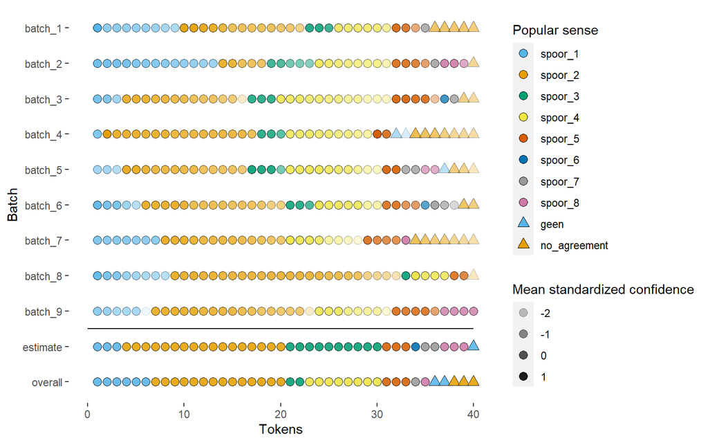

Figure 22. Distribution of majority senses of ‘spoor’ per batch

## Confusion matrix

The confusion matrix between the majority senses and other tagged senses can be seen in Table 23 (raw number of tokens with such senses assigned) and Table 24 (mean confidence of such sense annotation in each token).

We expect no overlap between homonyms, except maybe between *spoor_4* ‘trace-figurative’ and the “railway” senses. The metonymic relation between the senses of this second homonym are also probably harder to determine than those between the senses of the first one, but at the same time its low frequency makes it hard to compare.

There is indeed almost no overlap between homonyms. For *spoor_8* ‘spur’, there is only one case of confusion with a token with majority *spoor_2* ‘trace-evidence’ (and it must be a mistake in the annotation, because it makes no sense to apply *spoor_8* to it), and there are very few between the first two homonyms. The cases of *spoor_4* ‘trace-figurative’ where some annotator suggested *other_sense* only imply a less than perfect understanding of the definitions on the part of the annotator, since according to their comments they were identifying the right (figurative expression) meaning. Finally, 7.78% of the cases show no agreement between annotators, although the annotations themselves seem to carry low confidence. Most of them are disagreements between senses of the first homonym, but there are also some incomprehensible mistakes.

Table 23. Non weighted sense matrix of ‘spoor’ senses. Proportion of tokens with full agreement per sense-tag is: spoor_4: 0.54, spoor_2: 0.44, spoor_1: 0.25, spoor_7: 0.5, spoor_5: 0.71, spoor_8: 1, spoor_3: 0.41, spoor_6: 0.5. Proportion of tokens with full agreement per homonym is: traces: 0.88, railway: 0.93, spur: 1.

| senses | traces spoor_1 | traces spoor_2 | traces spoor_3 | traces spoor_4 | railway spoor_5 | railway spoor_6 | railway spoor_7 | spur spoor_8 | geen between | geen other_sense | geen unclear | geen wrong_lemma | total |
| --- | --- | --- | --- | --- | --- | --- | --- | --- | --- | --- | --- | --- | --- |
| spoor_1 | 55 | 32 | 4 | 4 | 0 | 0 | 0 | 0 | 0 | 1 | 0 | 0 | 55 |
| spoor_2 | 41 | 129 | 10 | 14 | 0 | 0 | 0 | 1 | 0 | 2 | 4 | 0 | 129 |
| spoor_3 | 5 | 10 | 22 | 1 | 0 | 0 | 1 | 0 | 0 | 0 | 0 | 0 | 22 |
| spoor_4 | 5 | 14 | 0 | 72 | 2 | 0 | 0 | 0 | 0 | 7 | 5 | 0 | 72 |
| spoor_5 | 1 | 0 | 0 | 2 | 31 | 3 | 3 | 0 | 0 | 0 | 0 | 0 | 31 |
| spoor_6 | 0 | 0 | 0 | 0 | 1 | 2 | 0 | 0 | 0 | 0 | 0 | 0 | 2 |
| spoor_7 | 0 | 0 | 0 | 0 | 2 | 2 | 8 | 0 | 0 | 0 | 0 | 0 | 8 |
| spoor_8 | 0 | 0 | 0 | 0 | 0 | 0 | 0 | 10 | 0 | 0 | 0 | 0 | 10 |
| other_sense | 0 | 0 | 0 | 0 | 1 | 0 | 0 | 0 | 0 | 1 | 0 | 0 | 1 |
| unclear | 1 | 0 | 0 | 0 | 0 | 0 | 1 | 0 | 0 | 0 | 2 | 0 | 2 |
| no_agreement | 19 | 20 | 5 | 12 | 3 | 3 | 0 | 4 | 2 | 9 | 7 | 1 | 28 |
| total | 127 | 205 | 41 | 105 | 40 | 10 | 13 | 15 | 2 | 20 | 18 | 1 | 0 |

Overall, the confidence given to the annotations of this lemma is quite low, except for the *spoor_8* ‘spur’ (the only one of its homonym) and *spoor_5* ‘railway’. This probably has to do with the high number of possible senses within each homonym and the difficulty to distinguish between them in the context given by the concordance.

Table 24. Weighted sense matrix of ‘spoor’ senses

| senses | spoor_1 | spoor_2 | spoor_3 | spoor_4 | spoor_5 | spoor_6 | spoor_7 | spoor_8 | between | other_sense | unclear | wrong_lemma |
| --- | --- | --- | --- | --- | --- | --- | --- | --- | --- | --- | --- | --- |
| spoor_1 | 3.47 | 3.44 | 3.5 | 2.5 | 0 | 0 | 0 | 0 | 0 | 0 | 0 | 0 |
| spoor_2 | 3.59 | 3.77 | 3.5 | 3.43 | 0 | 0 | 0 | 3 | 0 | 2.5 | 2.75 | 0 |
| spoor_3 | 3.4 | 3.4 | 3.89 | 2 | 0 | 0 | 5 | 0 | 0 | 0 | 0 | 0 |
| spoor_4 | 2.2 | 3.21 | 0 | 3.53 | 4.5 | 0 | 0 | 0 | 0 | 3.14 | 1.2 | 0 |
| spoor_5 | 2 | 0 | 0 | 2 | 4.04 | 5 | 3.67 | 0 | 0 | 0 | 0 | 0 |
| spoor_6 | 0 | 0 | 0 | 0 | 5 | 3.33 | 0 | 0 | 0 | 0 | 0 | 0 |
| spoor_7 | 0 | 0 | 0 | 0 | 1 | 2.5 | 3.92 | 0 | 0 | 0 | 0 | 0 |
| spoor_8 | 0 | 0 | 0 | 0 | 0 | 0 | 0 | 4.28 | 0 | 0 | 0 | 0 |
| other_sense | 0 | 0 | 0 | 0 | 5 | 0 | 0 | 0 | 0 | 3 | 0 | 0 |
| unclear | 2 | 0 | 0 | 0 | 0 | 0 | 5 | 0 | 0 | 0 | 1.5 | 0 |
| no_agreement | 2.32 | 3.05 | 3.2 | 2.33 | 3.67 | 3 | 0 | 2.5 | 0 | 2.44 | 1.71 | 5 |

## Nephology of *spoor*

My first impression on the clouds relates to the stress values of the dimensionality reduction and the parameters that make the strongest distinctions between models. We have 144 models of *spoor* created on 11/03/2020, modeling between 342 and 360 tokens. The stress value of the MDS solution for the cloud of models is 0.146.

The most dividing parameter is `FOC-POS`, splitting the cloud of models along the vertical dimension. Within each half, the most clear divisions are made by `PPMI` (Figure 23), particularly in the `FOC-POS:all` area, which is more disperse. In each of those groups, `FOC-WIN` and `SOC-WIN` split the models in orthogonal dimensions, especially with `FOC-POS:all + PPMI:selection`, where `SOC-WIN` seems stronger, and `FOC-POS:all + PPMI:no`, but to a lesser degree in the rest of the groups (maybe just because they are more cluttered; see Figure 24). The stress values of the MDS solutions of these models range between 0.236 and 0.279.

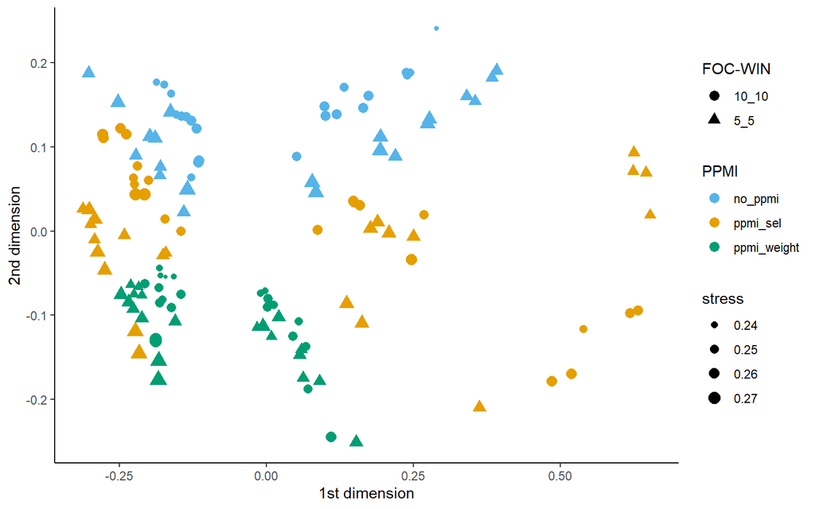

Figure 23. Cloud of models of ‘spoor’ colored by `PPMI`. Explore it [here](https://montesmariana.github.io/NephoVis/level1.html?type=spoor).

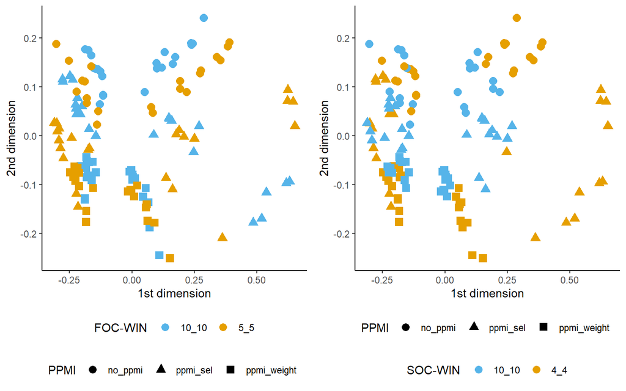

Figure 24. Cloud of models of ‘spoor’ colored by `FOC-WIN` (left) and `SOC-WIN` (right). Explore it [here](https://montesmariana.github.io/NephoVis/level1.html?type=spoor).

In order to compare the strongest parameters, but also accounting for the interaction between `PPMI`, `FOC-WIN` and `SOC-WIN`, I’ll first fix `LENGTH:FOC + SOC-POS:nav` and then alternatively select different values of `PPMI`. At the end I also (briefly) compared `LENGTH:FOC` with `LENGTH:5000` and the difference was quite small and not necessarily an improvement.

With any `PPMI`, the parameter that seems to make the least difference is `SOC-WIN`, but it does depend on the values of `FOC-POS` and `FOC-WIN`. With `FOC-POS:nav` the differences range between 0.11 and 0.20, against a range of 0.20 to 0.68 with `FOC-POS:all`; the values increase slightly with `FOC-WIN:10` if `PPMI:selection` and decrease otherwise. All in all, the `FOC-POS:all + SOC-WIN:4` models have the highest distance values, but only with `PPMI:no + FOC-WIN:all + FOC-POS:nav`, in the t-SNE solution of perplexity 30, did I find a setting of `SOC-WIN` to make a significant improvement. Therefore, we could just default.

Given `PPMI:weight`, the models don’t look very different from each other in the MDS solutions; `FOC-POS:all` models with other `PPMI` values are more sensitive to one or two outliers. Only the t-SNE solutions (from perplexity 20) show more distinct clusters with `FOC-POS:all`. In any case, at most two small dense clusters can be distinguished from the greater, disperse mass without color coding.

Color coding lets us see that the “spur” and “railway” homonyms do tend to stick together in MDS and are more compact in `FOC-POS:all` models. The difference is more evident in `PPMI:selection | PPMI:no`. The “spur” homonym has its own cluster in the t-SNE solutions, but it’s so infrequent that it’s very tiny; “railway” forms clusters that don’t stray far away from the main mass and is better rendered `FOC-WIN:10` and improved with `FOC-POS:all` for `PPMI:weight` or `FOC-POS:nav` otherwise. There are too many sense tags[^4] to expect much clarity in the clouds; in principle, it would seem that *spoor_3* ‘traces-substance’ and *spoor_4* ‘trace-figurative’ stay apart in MDS solutions, and rather compact with `FOC-POS:all`, while there is some overlap between *spoor_3* ‘traces-substance’ and *spoor_2* ‘traces-evidence’ and *spoor_1* ‘trace-footprint’ is all over the place. The t-SNE solutions don’t look totally random but it’s still hard to find structure in them: those with perplexity 5 are scattered archipelagos and those with perplexity 50 are almost uniform masses; perplexity 30 seems to render the structure a bit better than 20. There are some clusters and they are more compact and have better separability in `PPMI:weight` models overall (`FOC-WIN:10` seems to work particularly well). There is a cluster of *spoor_1* ‘trace-footprint’ and *spoor_2* ‘traces-evidence’ corresponding to the expression “sporen nalaten”; some for *spoor_3* ‘traces-substance’, *spoor_4* ‘trace-figurative’, *spoor_8* ‘spur’ and *spoor_5* ‘railway-main’ as well as a rather populated one with cases of “spoor van de daders”. The t-SNE models have also revealed a number of interesting tokens that keep occurring in the neighborhood of clusters to which they don’t “really” belong. The concordances are reproduced and discussed in the visitors subsection.

> For further insight I would look into `FOC-WIN:10 + PPMI:weight + SOC-WIN:4 + SOC-POS:nav + LENGTH:FOC` and try to figure out how `FOC-POS` actually impacts the clusters, especially in t-SNE models with perplexity 30.

### Visitors

The tokens transcribed in (18) through (20) consistently (in `PPMI:weight` models) occur inside or next to groups to which a human wouldn’t classify them. I find them interesting as examples of the discrepancies between what the model does and what a human interpreter would do.

Example (18) was unanimously assigned the *spoor_1* ‘trace-footprint’ tag (with confidences of 2, 5 and 5) but `FOC-WIN:10 + PPMI:weight` models, which unlike their `FOC-WIN:5` counterparts group the “railway” tokens tightly together, place that token *in the middle* of the “railway” cluster.

18. opgetrommeld voor het opruimen van een kilometerslang oliespoor op de Waregemseweg . *Het* spoor *liep* zelfs tot aan *het* *station* *van* Anzegem , zodat ook de brandweer van Anzegem

Examples (19) and (20) both tend to orbit the *spoor_4* “op het (goede) spoor zetten” cluster, even in `FOC-WIN:5` models that don’t hold the cluster so tight. The former was assigned the *spoor_7* ‘railway-company’ tag with confidences of 4 and 5 and the *spoor_6* ‘railway-train’ tag with confidence of 2, while the latter was assigned the *spoor_5* ‘railway-main’ tag by one annotator, with maximum confidence, and the *geen* ‘none of the above’ tag with confidence of 3 by the other two, both making reference to the fact that it was a fixed expression (one even specified: “op de sporen zetten”). Here, the systematicity of the model allowed us to cluster two tokens where the annotators were lost, maybe because of the order in which they annotated, because the sense was not so clear to them compared to the other 2 or 3 tokens of that expression in their batch.

19. om een staatshervorming , wordt zo misschien toch *een* stap *gezet* *richting* *regionalisering* *van* *het* spoor . " Al moet de federale niet te veel verwachten , in onze
20. de wetenschap en de journalisten om *een* leefbaar *alternatief* voor *de* *verwoestende* agro-industrie *op* *de* sporen te *zetten* . S. De Clercq / Wevelgem Bio is gezonder
[^1]: It would seem our instructions were not clear enough. All three annotators agreed on the sense tag for this instance of *horde*, which is “right”, except that it’s *not Dutch*.
[^2]: These 12 tokens all come from *Het Nieuwsblad*, between 2003 and 2004, and occur in the 9th position of their respective articles.
[^3]: This comparison was performed on models with `SOC-POS:nav + PPMI:weight | PPMI:no`. Given `LENGTH:FOC`, distances between models varying only in `FOC-WIN` range between 0.27 and 0.59 and are higher with `PPMI:no`, and for models varying only in `SOC-WIN`, between 0.24 and 0.42 and are higher with `PPMI:weight`, except for the one with least restrictions, where the distance is 0.69.
[^4]: I merged the two *geen* ‘none of the above’ tags (*unclear* and *other_sense*) to avoid having more than 10 values in the categorical variable “popular” for *spoor*.

Mariana Montes

2020-03-17